# Analyses

# Setup

```r
rm(list = ls())

# Load required libraries
library(tidyverse)
library(here)
library(ape)
library(tidytree)
library(castor)
library(phylobase)
library(testthat)
library(kableExtra)
library(ggtree)
library(car)
library(MuMIn)
library(glmmTMB)
library(DHARMa)
library(performance)
library(lme4)
library(coin)
library(rdist)
library(apaTables)
library(bbmle)
library(janitor)      # for turning a row into column names
library(MASS)
# set options
options(na.action = "na.omit")
select <- dplyr::select
drop.tip <- ape::drop.tip
summarise <- dplyr::summarise

set.seed(302)

languages <- c("Anindilyakwa",
               "Innu",
               # "Rangi",
               "Saami",
               "Tlingit",
               "Tobelo",
               "Tzeltal",
               "Zapotec")

languages_plus <- c(languages,
               "All")

colour_pairs <- list(
  Anindilyakwa = c("#ffe0f1", "#ff1493"),       #deeppink
  Innu = c("#fae2e2", "#cd2626"),         #firebrick
  Saami = c("#ffe7d7", "#cd6600"),              #darkorange
  Tlingit = c("#fff9d7", "#cdad00"),              #gold
  Tobelo = c("#d7ffeb", "#00ee76"),            #springgreen
  # Tobelo = c("#00e5ee", "#00c5cd"),             #turquoise
  Tzeltal = c("#e2f1ff", "#1e90ff"),            #dodgerblue
  Zapotec = c("#f7e6ff", "#bf3eff"),             #darkorchid
  All = c( "#e8e0ef", "#675875")                 #plummy
  )
```

# Descriptive Stats

## Shapiro tests for AVONET variables

```r
bird_data <- read.csv(here("data/bird_data.csv")) %>%
  filter(Language %in% languages)

Shapiro <- bird_data %>%
  select(Language, BeakLengthCulmen:Mass) %>%
  filter(complete.cases(.[sapply(., is.numeric)])) %>%
  group_by(Language) %>%
  summarise(across(BeakLengthCulmen:Mass, ~ shapiro.test(.)$p.value, .names = "{.col}"))
```

# Hunn Correspondence Measure

Use Hunn’s measure to compare folk categories with Clements 1974 and Clements 2023 taxonomies

## Define Functions

```r
format_nicely <- function(x) {
  sapply(x, function(val) {
    if (abs(val) < 1 | abs(val) == 0) {
      no_0 <- formatC(val, format = "f", digits = 2)
      sub("^0+", "", no_0)
    } else {
      no_0 <- formatC(val, format = "f", digits = 0)
      sub("^0+", "", no_0)
    }
  })
}

# initial downward pass described by Hunn
hunn_phase1 <- function(currnode, p4, members) {

  # Identify the descendants of the node in the tree
  ds <- descendants(p4, currnode)

  # Identify which descendants are in the FG group
  ds_members <- intersect(ds, members)

  # If none of the FG group members are in this node, return NULL
  if ( length(ds_members) == 0 ) {
    return(NULL)

    # if all of the FG members are in the current node, return the node
  } else if ( length(ds) == length(ds_members) ) {
    return(currnode)
  }

  # Initialise empty result
  result <- NULL

  # recursively apply the function to each child of the current node
  for (c in children(p4, currnode)) {
    result <- union(result, hunn_phase1(c, p4, members))
  }
  return(result)
}


# compute dissimilarity of members of FG with respect to phylogeny p
hunn_match_members <- function(p, members) {

  # If there is only one thing in the FG group, its dissimilarity is 0
  if ( length(members) == 1 ) {
    return(0)
  }
  p4 <- as(p, "phylo4")
  r <-  rootNode(p4)
  phase1 <- hunn_phase1(r, p4, members)

  # if the result from initial downward pass is 1, the taxon perfectly matches a taxon in the traditional taxonomy.
  if ( length(phase1) == 1 ) {
    return(0)

  } else {

    # Identify most recent common ancestor of nodes that contain members of the taxon
    lcd  <- phylobase::MRCA(p4, phase1)
    lcds <- rep(lcd, length(phase1))
    # Get pairwise distances between all nodes that contain members of the taxon, and return the longest one.
    pwds <- get_pairwise_distances(p,
                                   phase1,
                                   lcds,
                                   as_edge_counts = FALSE,
                                   check_input = TRUE)
    return(max(pwds))
  }
}

# Get the scores for the entire taxonomy - which categories
score_tree <- function(l_tree, data, special_cases) {
  l_tree_tidy <- l_tree %>%
    as.treedata() %>%
    as_tibble()

  l_names <- data %>%
    rename(label = "canonical_name") %>%
    left_join(l_tree_tidy, by = "label")

  expect_equal(nrow(l_names), nrow(data))

  l_members <- l_names %>%
    group_by(IndexFG) %>%
    summarise(node_indices = list(unique(node)))

  l_hunnscores <- l_members %>%
    mutate(hunn_score = map_dbl(node_indices, ~hunn_match_members(l_tree, .x))) %>%
    # Special cases for overdifferentiated birds
    mutate(hunn_score = ifelse(IndexFG %in% special_cases$IndexFG,
           hunn_score + 1,
           hunn_score)) %>%
    arrange(desc(hunn_score))

  avg_score <-  mean(l_hunnscores$hunn_score)
  zero_propn <- sum(l_hunnscores$hunn_score == 0) / nrow(l_hunnscores)
  #browser()
  return( list(avg_score, zero_propn, l_hunnscores) )
}

# compute measure for 23 and 74 trees for language THIS_LANGUAGE
process_language <- function(this_language, bird_data) {

  print(this_language)
  this_language_title <- str_to_title(this_language)

  treepath_74 <-  here("data", paste0("tree_74_", this_language, ".nex"))
  treepath_23 <-  here("data", paste0("tree_23_", this_language, ".nex"))

  l_data <- bird_data %>%
    filter(Language == {{this_language_title}})

  special_cases <- l_data %>%
    group_by(ScientificName2023) %>%
    filter(n() > 1)

  l_74_raw <- read.nexus(file = treepath_74)
   l_74 <- as.ultrametric(compute.brlen(l_74_raw, 1)) %>%
    normalise_lengths() %>%
     standardise_names(l_data, ScientificName1974)

  l_74$root.edge = find_root(l_74)
  d_74 <- as_tibble(l_74)
  plot_74 <- ggtree(l_74)

  l_23_raw <- read.nexus(file = treepath_23)
  l_23 <- as.ultrametric(compute.brlen(l_23_raw, 1))  %>%
     normalise_lengths()
  l_23$root.edge = find_root(l_23)
  d_23 <- as_tibble(l_23)
  plot_23 <- ggtree(l_23)

  plot_all <-  plot_74 + plot_23
  show(plot_all)

  labs_all <- tibble(canonical_name = tip.label(l_74), tree = "74")  %>%
    bind_rows( tibble(canonical_name = tip.label(l_23), tree = "23") )

  labs_wide <- labs_all %>%
    pivot_wider(names_from = tree, values_from = tree)

  # should be no missing labels from 23 tree
  expect_equal(sum(is.na(labs_wide$`23`)), 0)

  labs_shared <- labs_all %>%
    group_by(canonical_name) %>%
    summarise(count = n())

  l_74 <- l_74 %>% normalise_avg_dist()
  l_23 <- l_23 %>% normalise_avg_dist()

  if (1) { # plot trees after distance normalization
  plot_74 <- ggtree(l_74)
  plot_23 <- ggtree(l_23)
  plot_all <- plot_74 + plot_23
  show(plot_all)
  }

  data_74 <- labs_shared %>%
    filter(count == 2) %>%  # each species in labs_shared appears only in l_23 or in both l_74 and l_23
    left_join(l_data, by = "canonical_name") %>%
    select(canonical_name, IndexFG)

  data_23 <- labs_shared %>%
    left_join(l_data, by = "canonical_name") %>%
    select(canonical_name, IndexFG)

  score_74 <- score_tree(l_74, data_74, special_cases)
  score_23 <- score_tree(l_23, data_23, special_cases)

  # This returns a tibble containing the scores for how similar the folk taxonomies are to the traditional scientific ones
  scores <- tibble(tree = c("74", "23"),
                   avg_score = c(score_74[[1]],
                                 score_23[[1]]),
                   zero_propn = c(score_74[[2]],
                                  score_23[[2]]),
                   category_scores = c(list(score_74[[3]]),
                                       list(score_23[[3]])))

return(scores)
}

standardise_names <- function(tree, fulldata, currname) {
  label_map <- fulldata %>%
    mutate(old = {{currname}}) %>%
    select(old, canonical_name)

  newlabel <-  tibble(old = tree$tip.label) %>%
    left_join(label_map, by = "old") %>%
    # when there are duplicate values of old, keep first row only. If the duplicates have the same folk labels, it doesn't matter which row we pick, so the approach here is if. If the duplicates have different folk labels we'll need to handle them as a special case. The cases in manual_check_needed should be inspected to see if there are any that need special treatment.
    distinct(old, .keep_all = TRUE)

  expect_equal(nTips(tree), nrow(newlabel))

  tree$tip.label = newlabel$canonical_name
  return(tree)
}

normalise_lengths <- function(tree) {
  max_height <- max(get_all_distances_to_root(tree))
  tree$edge.length = tree$edge.length / 5
  return(tree)
}

normalise_avg_dist<- function(tree) {
  #ds <- get_all_pairwise_distances(tree)
  #avg_dist <- mean(ds[lower.tri(ds)])

  # normalize average distance between tips
  #tree$edge.length = tree$edge.length / avg_dist

  # make all branches uniform
  tree$edge.length = tree$edge.length / tree$edge.length
  return(tree)
}
```

## Run Analysis

```
[1] "anindilyakwa"
```

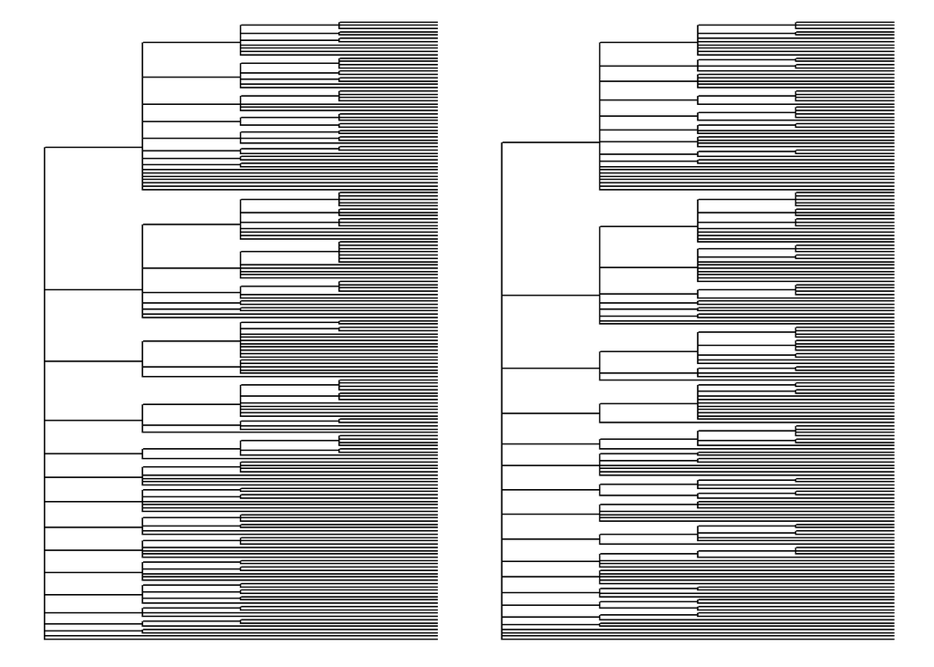

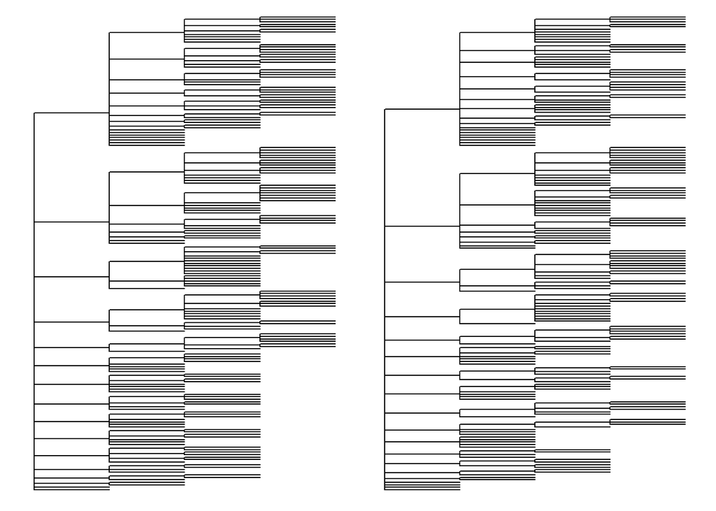

```
[1] "innu"
```

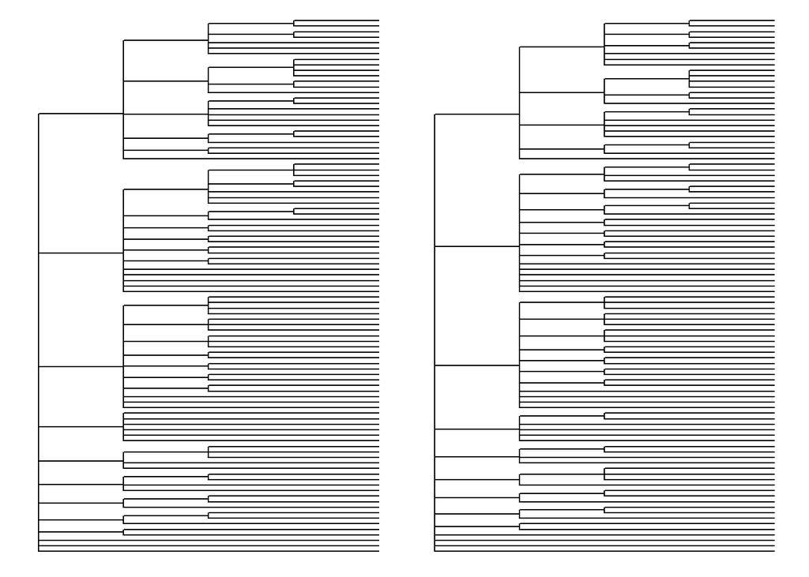

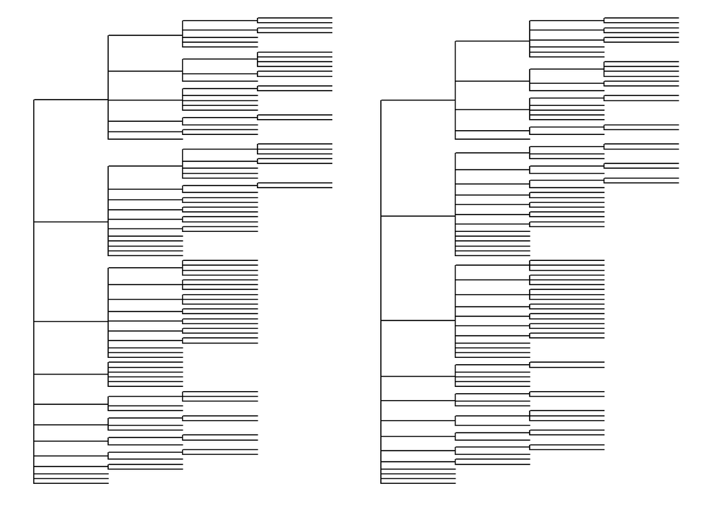

```
[1] "saami"
```

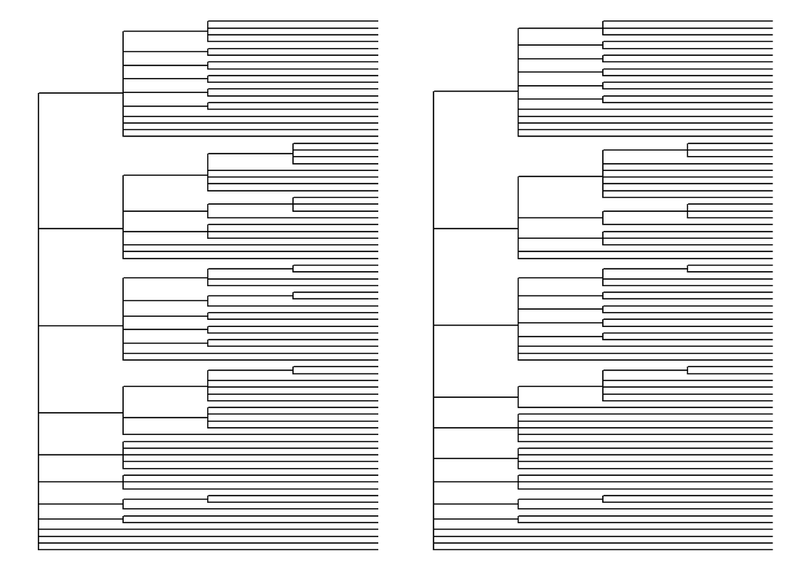

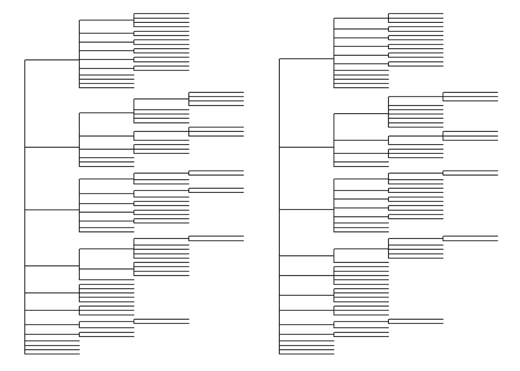

```
[1] "tlingit"
```

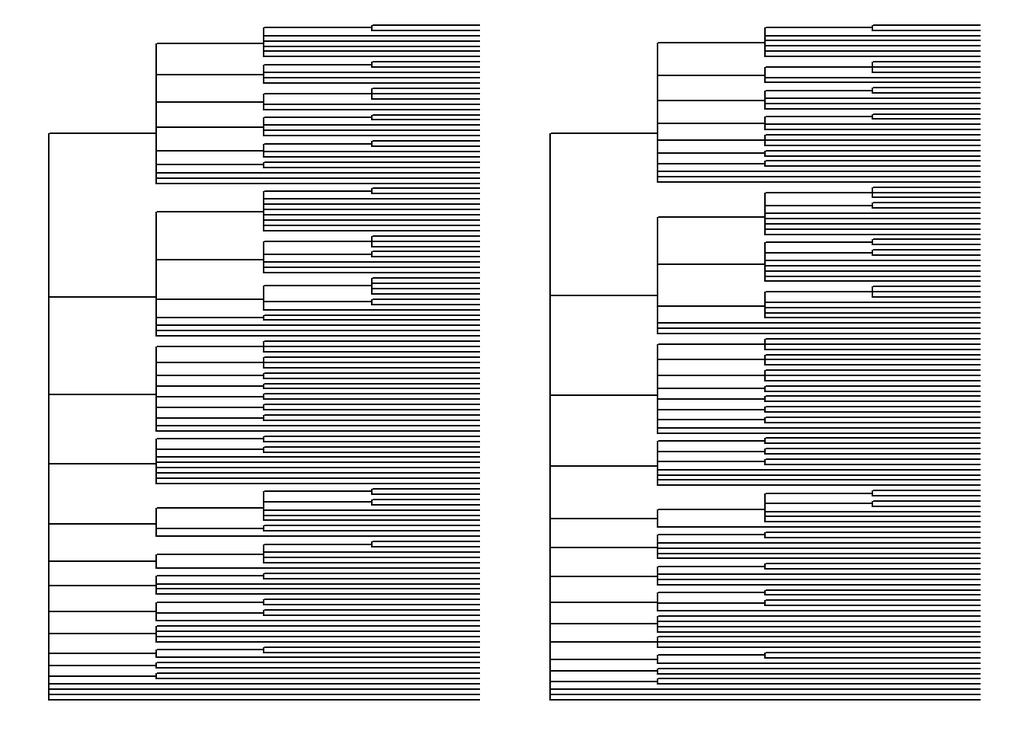

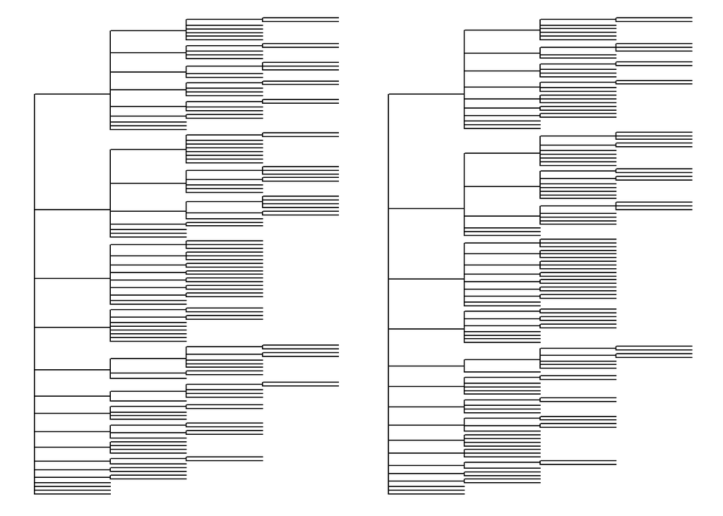

```
[1] "tobelo"
```

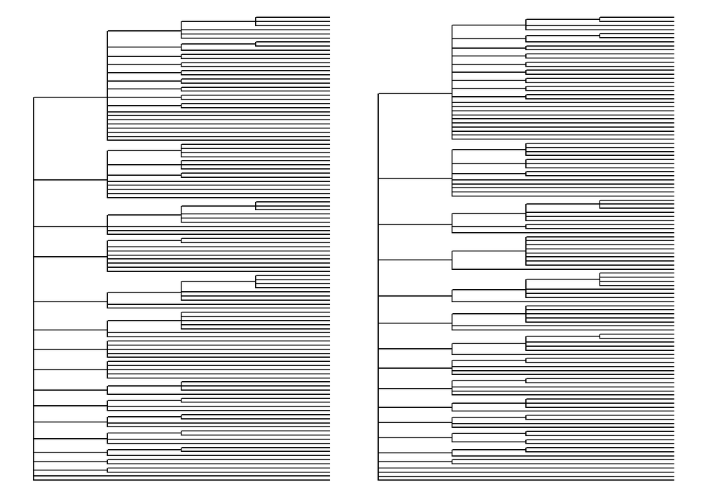

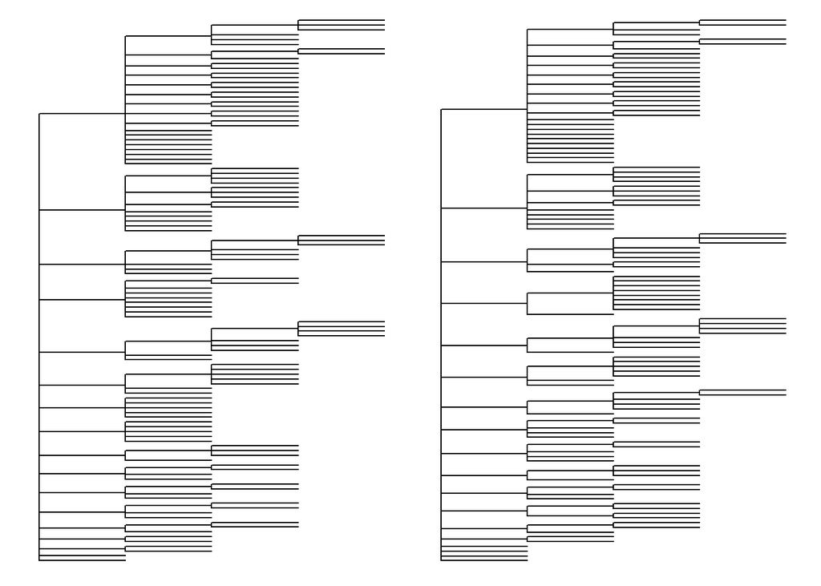

```
[1] "tzeltal"
```

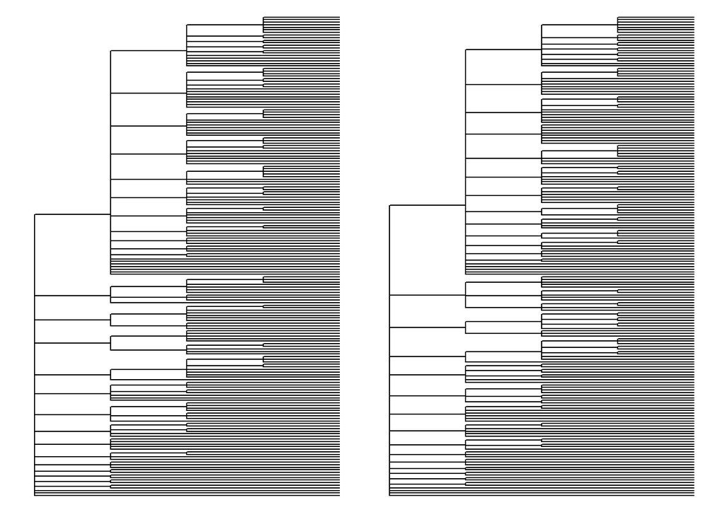

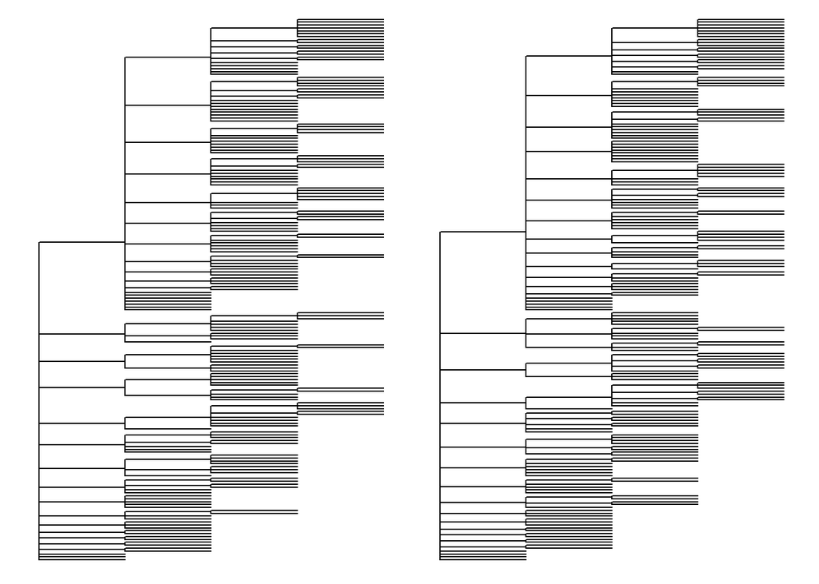

```
[1] "zapotec"
```

[2 more figures not shown]

```r
all_scores <- tibble(language = c("anindilyakwa",
               "innu",
               # "rangi",
               "saami",
               "tlingit",
               "tobelo",
               "tzeltal",
               "zapotec"))

bird_data <- bird_data %>%
  mutate(canonical_name = str_remove(ScientificName2023, "\\.\\d"))

# canonical names for this notebook are based on ScientificName2023. Here we identify cases that may require manual attention. These include cases where folk names are overdifferentiated with respect to ScientificName2023, or cases where two species with different canonical names have the same ScientificName1974 label

manual_check_needed <- bird_data %>%
  group_by(Language, canonical_name) %>%
  mutate(n_canonical = n()) %>%
  ungroup() %>%
  group_by(Language, ScientificName1974) %>%
  mutate(n_74 = n()) %>%
  filter(n_74 > 1 | n_canonical > 1 | is.na(ScientificName1974))

# After checking the manual_check_needed, if all the birds are fine, change the number below to the number of rows in manual_check_needed then run this chunk again
expect_equal(nrow(manual_check_needed), 23)

all_scores <- all_scores %>%
  mutate(s = purrr::map(language, ~process_language(.x, bird_data))) %>%
  unnest(s)
```

```r
all_scores %>%
  select(-category_scores) %>%
  kable() %>%
  kable_styling()
```

| language | tree | avg_score | zero_propn |
| --- | --- | --- | --- |
| anindilyakwa | 74 | 0.5844156 | 0.7142857 |
| anindilyakwa | 23 | 0.5974026 | 0.7142857 |
| innu | 74 | 0.3555556 | 0.7777778 |
| innu | 23 | 0.3777778 | 0.7333333 |
| saami | 74 | 0.1428571 | 0.8928571 |
| saami | 23 | 0.1428571 | 0.8928571 |
| tlingit | 74 | 0.1627907 | 0.8837209 |
| tlingit | 23 | 0.1976744 | 0.8604651 |
| tobelo | 74 | 0.3589744 | 0.7820513 |
| tobelo | 23 | 0.3717949 | 0.7692308 |
| tzeltal | 74 | 0.1886792 | 0.8490566 |
| tzeltal | 23 | 0.1886792 | 0.8679245 |
| zapotec | 74 | 0.4117647 | 0.7500000 |
| zapotec | 23 | 0.3970588 | 0.7647059 |

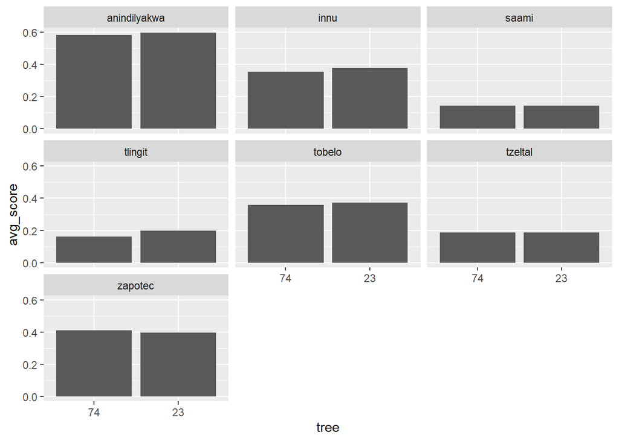

```r
score_plot <- all_scores %>%
  mutate(tree= factor(tree, levels = c("74", "23")))  %>%
  ggplot(aes(x=tree, y = avg_score)) +
  geom_col() +
  facet_wrap(~language)

show(score_plot)
```

## Comparing 1974 and 2023 trees

```r
compare_74_23_long <- all_scores %>%
  unnest(category_scores) %>%
  filter(tree == "74" | tree == "23") %>%
  select(language, tree, IndexFG, hunn_score)

compare_74_23_wide <- compare_74_23_long %>%
  pivot_wider(values_from = hunn_score, names_from=tree) %>%
  mutate(diff_74_23 = `74`- `23`)

diff_counts <- compare_74_23_wide %>%
  group_by(language) %>%
  summarise(better_74 = sum(diff_74_23 < 0), better_23 = sum(diff_74_23 > 0), .groups = "drop" )

differences <- compare_74_23_wide %>%
  filter(diff_74_23 != 0) %>%
  arrange(diff_74_23)

differences %>%
   kable() %>%
   kable_styling()
```

| language | IndexFG | 74 | 23 | diff_74_23 |
| --- | --- | --- | --- | --- |
| anindilyakwa | Ani.36 | 3 | 4 | -1 |
| anindilyakwa | Ani.25 | 2 | 3 | -1 |
| anindilyakwa | Ani.33 | 2 | 3 | -1 |
| anindilyakwa | Ani.34 | 1 | 2 | -1 |
| anindilyakwa | Ani.56 | 0 | 1 | -1 |
| innu | Mon.18 | 0 | 1 | -1 |
| innu | Mon.6 | 0 | 1 | -1 |
| saami | Saa.47 | 2 | 3 | -1 |
| tlingit | Tli.3 | 2 | 3 | -1 |
| tlingit | Tli.60 | 0 | 1 | -1 |
| tlingit | Tli.76 | 0 | 1 | -1 |
| tobelo | Tob.34 | 1 | 2 | -1 |
| tobelo | Tob.71 | 1 | 2 | -1 |
| tobelo | Tob.39 | 0 | 1 | -1 |
| tzeltal | Tze.56 | 1 | 2 | -1 |
| tzeltal | Tze.76 | 1 | 2 | -1 |
| zapotec | Zap.47 | 0 | 1 | -1 |
| anindilyakwa | Ani.47 | 4 | 3 | 1 |
| anindilyakwa | Ani.73 | 2 | 1 | 1 |
| anindilyakwa | Ani.9 | 2 | 1 | 1 |
| anindilyakwa | Ani.51 | 1 | 0 | 1 |
| innu | Mon.43 | 3 | 2 | 1 |
| saami | Saa.19 | 2 | 1 | 1 |
| tobelo | Tob.4 | 4 | 3 | 1 |
| tobelo | Tob.30 | 2 | 1 | 1 |
| tzeltal | Tze.23 | 1 | 0 | 1 |
| tzeltal | Tze.31 | 1 | 0 | 1 |
| zapotec | Zap.23 | 1 | 0 | 1 |
| zapotec | Zap.45 | 1 | 0 | 1 |

```r
summary_74_23 <- compare_74_23_long %>%
  group_by(language, tree) %>%
  summarise(n = n(), zero_propn = sum(hunn_score == 0), avg_score = mean(hunn_score), .groups = "drop")  %>%
  left_join(diff_counts, by = "language") %>%
  mutate(avg_score = round(avg_score, 3)) %>%
  mutate(n_improve = if_else(tree == "74", better_74, better_23)) %>%
  select(-better_74, -better_23) %>%
  arrange(language, desc(tree))

summary_74_23 %>%
  kable() %>%
  kable_styling()
```

| language | tree | n | zero_propn | avg_score | n_improve |
| --- | --- | --- | --- | --- | --- |
| anindilyakwa | 74 | 77 | 55 | 0.584 | 5 |
| anindilyakwa | 23 | 77 | 55 | 0.597 | 4 |
| innu | 74 | 45 | 35 | 0.356 | 2 |
| innu | 23 | 45 | 33 | 0.378 | 1 |
| saami | 74 | 56 | 50 | 0.143 | 1 |
| saami | 23 | 56 | 50 | 0.143 | 1 |
| tlingit | 74 | 86 | 76 | 0.163 | 3 |
| tlingit | 23 | 86 | 74 | 0.198 | 0 |
| tobelo | 74 | 78 | 61 | 0.359 | 3 |
| tobelo | 23 | 78 | 60 | 0.372 | 2 |
| tzeltal | 74 | 106 | 90 | 0.189 | 2 |
| tzeltal | 23 | 106 | 92 | 0.189 | 2 |
| zapotec | 74 | 68 | 51 | 0.412 | 1 |
| zapotec | 23 | 68 | 52 | 0.397 | 2 |

The summary table shows the number of categories with dissimilarity of 0 – ie the number that match the scientific taxonomy perfectly. It also includes the average dissimilarity for each language with respect to each taxonomy, and the number of categories that match one taxonomy better than the other taxonomy.

## Get confidence intervals

```r
compute_bstrap_mean <- function(d)  {
  out <- d %>%
    group_by(language, tree) %>%
    slice_sample(prop=1, replace=TRUE) %>%
    summarise(mean_score = mean(hunn_score), .groups = "drop")
}

bstrap <- tibble(n = 1:10000) %>%
  mutate(samp = purrr::map(n, ~compute_bstrap_mean(compare_74_23_long)))  %>%
  unnest(samp) %>%
  group_by(language, tree) %>%
  dplyr::summarise(low_95 = quantile(mean_score, 0.025), high_95 = quantile(mean_score, 0.975), median = quantile(mean_score, 0.5), .groups = "drop") %>%
  arrange(language, desc(tree))

bstrap %>%
   kable() %>%
   kable_styling()
```

| language | tree | low_95 | high_95 | median |
| --- | --- | --- | --- | --- |
| anindilyakwa | 74 | 0.3636364 | 0.8181818 | 0.5844156 |
| anindilyakwa | 23 | 0.3766234 | 0.8311688 | 0.5974026 |
| innu | 74 | 0.1555556 | 0.6000000 | 0.3555556 |
| innu | 23 | 0.1777778 | 0.6000000 | 0.3777778 |
| saami | 74 | 0.0357143 | 0.2678571 | 0.1428571 |
| saami | 23 | 0.0357143 | 0.2857143 | 0.1428571 |
| tlingit | 74 | 0.0697674 | 0.2790698 | 0.1627907 |
| tlingit | 23 | 0.0930233 | 0.3255814 | 0.1976744 |
| tobelo | 74 | 0.2051282 | 0.5384615 | 0.3589744 |
| tobelo | 23 | 0.2179487 | 0.5384615 | 0.3717949 |
| tzeltal | 74 | 0.1037736 | 0.2924528 | 0.1886792 |
| tzeltal | 23 | 0.0943396 | 0.2924528 | 0.1886792 |
| zapotec | 74 | 0.2352941 | 0.6029412 | 0.4117647 |
| zapotec | 23 | 0.2205882 | 0.6029412 | 0.3970588 |

The bootstrap table shows bootstrapped confidence intervals on the average dissimilarity for each language and taxonomy. These intervals are very wide, which means that the differences in average dissimilarity across taxonomies are not statistically significant.

## Make a nice table

```r
table_hunn <- summary_74_23 %>%
  left_join(bstrap, by = c("language", "tree")) %>%
  mutate(prop = zero_propn/n) %>%
  mutate_if(is.numeric, round, 2) %>%
  mutate(language = make.unique(language)) %>%
  select(language, tree, n, prop, avg_score, n_improve, low_95, high_95) %>%
  t() %>%
  as.data.frame() %>%
  row_to_names(row_number = 1) %>%
  filter(rownames(.) != "median") %>%
  mutate_all(as.numeric) %>%
  mutate(all = ifelse(row.names(.) %in% c("n", "n_improve"),
                    rowSums(select(., !contains(".")), na.rm = TRUE),
                    rowMeans(select(., !contains(".")), na.rm = TRUE))) %>%
  mutate(all.1 = ifelse(row.names(.) %in% c("n", "n_improve"),
                    rowSums(select(., contains(".")), na.rm = TRUE),
                    rowMeans(select(., contains(".")), na.rm = TRUE))) %>%
  mutate_all(~format_nicely(.))




rownames_hunn <- c("Tax.",
                   "$n$",
                   "$prop\\textsubscript0$",
                   "$D$",
                   "$Imp.$",
                   "CI lower",
                   "CI upper")

kable_hunn <-
  table_hunn

rownames(kable_hunn) <- rownames_hunn

kable_hunn <- kable_hunn %>%
  kable(col.names = NULL,
        format = "latex",
        escape = FALSE,
        align = c(rep("c", 14)),
                booktabs = TRUE,
                caption = "Comparison between folk taxonomies and 1974 and 2023 Clements taxonomies",
                label = "table:hunn") %>%
  kable_styling(latex_options = c("hold_position",
                                    "scale_down")) %>%
  column_spec(2:ncol(table_hunn), width = ".75cm") %>%
  add_header_above(c(" " = 1,
                     "Anindilyakwa" = 2,
                     "Innu" = 2,
                     "Saami" = 2,
                     "Tlingit" = 2,
                     "Tobelo" = 2,
                     "Tzeltal" = 2,
                     "Zapotec" = 2,
                     "All" = 2),
                   underline = FALSE)

kable_hunn <- gsub("0\\.", ".", kable_hunn)

write.csv(table_hunn, file = here("output/HunnCorrespondenceTable.csv"))
write_lines(kable_hunn, here("output/HunnCorrespondenceTable.tex"))

table_hunn
```

|  | anindilyakwa | anindilyakwa.1 | innu | innu.1 | saami | saami.1 | tlingit | tlingit.1 | tobelo | tobelo.1 | tzeltal | tzeltal.1 | zapotec | zapotec.1 | all | all.1 |
| --- | --- | --- | --- | --- | --- | --- | --- | --- | --- | --- | --- | --- | --- | --- | --- | --- |
| tree | 74 | 23 | 74 | 23 | 74 | 23 | 74 | 23 | 74 | 23 | 74 | 23 | 74 | 23 | 74 | 23 |
| n | 77 | 77 | 45 | 45 | 56 | 56 | 86 | 86 | 78 | 78 | 106 | 106 | 68 | 68 | 516 | 516 |
| prop | .71 | .71 | .78 | .73 | .89 | .89 | .88 | .86 | .78 | .77 | .85 | .87 | .75 | .76 | .81 | .80 |
| avg_score | .58 | .60 | .36 | .38 | .14 | .14 | .16 | .20 | .36 | .37 | .19 | .19 | .41 | .40 | .31 | .33 |
| n_improve | 5 | 4 | 2 | 1 | 1 | 1 | 3 | .00 | 3 | 2 | 2 | 2 | 1 | 2 | 17 | 12 |
| low_95 | .36 | .38 | .16 | .18 | .04 | .04 | .07 | .09 | .21 | .22 | .10 | .09 | .24 | .22 | .17 | .17 |
| high_95 | .82 | .83 | .60 | .60 | .27 | .29 | .28 | .33 | .54 | .54 | .29 | .29 | .60 | .60 | .49 | .50 |

# Analysis 1: Predicting name-sharing

## Define functions

```r
# Function to round everything to 2 digits, unless it's smaller than .01

format_sensibly <- function(x) {
  sapply(x, function(val) {
    if (abs(val) < 0.01) {
      return("<.01")
    } else {
      no_0 <- formatC(val, format = "f", digits = 2)
      sub("^0+", "", no_0)
    }
  })
}

# Make fractional rankings to identify pairs of birds that sit differently in each of the spaces/taxonomies

frac_rank <- function(x) {
  if (all(is.na(x))) {
    return(rep(NA, length(x)))
  }
  rank_x <- rank(x, na.last = "keep")
  frac_rank <- ave(rank_x,
                   rank_x,
                   FUN = function(y) mean(y, na.rm = TRUE))
  return(frac_rank)
}
```

## Import Datasets

```r
bird_sim <- list()

for (language in languages) {

  file_path <- here("data", paste0("similarity_", language, ".csv"))
  similarity <- read.csv(file = file_path) %>%
    select(-X)

  # pop them all in a big list
  bird_sim[[str_to_title(language)]] <- similarity

}

### Take out duplicates
# when I created these datasets I put all of the duplicates in. This analysis is at the level of western scientific species so there shouldn't be duplicates of pairs of birds species, so I need to take them out but keep the ones where the names are the same.

bird_similarity <- list()

for (language in languages) {

  language_data <- bird_sim[[language]]

  language_data_filtered <- language_data %>%
    # change names so I can identify duplicates
    mutate_at(vars(contains("Species")),
              ~gsub("\\..*", "", .)) %>%
    # make sure that the pairs are always identifiable as the same pairs (I did this when I created the dataset but doing it again just in case)
    mutate(s1 = pmin(Species1,Species2),
           s2 = pmax(Species1,Species2)) %>%
    select(-contains("Species")) %>%
    rename(Species1 = s1,
           Species2 = s2) %>%
    # Put the TRUE values before the FALSE ones so they will be the ones that remain when I remove duplicates
    arrange(desc(SameName)) %>%
    # filter out duplicated pairs
    distinct(Species1, Species2, .keep_all = TRUE) %>%
    #filter out birds pairing with themselves
    filter(Species1 != Species2) %>%
    select(-contains("zDist")) %>%
    mutate_at(vars(starts_with("Dist")), list(z = ~scale(.)[,1])) %>%
    rename_at(vars(ends_with("_z")), ~sub("(.*)_z$", "z\\1", .))

  result <- length(which(duplicated(language_data_filtered[, c("Species1","Species2")])))

      if (result == 0) {
    message("No duplicates remain in ", language)
      } else {

        message("Oh no,", language, "still has duplicates!")
      }

  bird_similarity[[language]] <- language_data_filtered

}
```

```
No duplicates remain in Anindilyakwa
```

```
No duplicates remain in Innu
```

```
No duplicates remain in Saami
```

```
No duplicates remain in Tlingit
```

```
No duplicates remain in Tobelo
```

```
No duplicates remain in Tzeltal
```

```
No duplicates remain in Zapotec
```

## Correlations between dist measures

```r
cor_tables <- list()

for (language in languages) {

  language_data <- bird_similarity[[language]] %>%
    select(zDist74,
           zDist23,
           zDistPhy,
           zDistPer) %>%
    # This seems a bit silly but I want to be able to reorder them easily later
    rename(a74 = zDist74,
           b23 = zDist23,
           cPhy = zDistPhy,
           dPer = zDistPer)


cors <- cor(language_data) %>%
  as.data.frame() %>%
  rename_with(~ paste0(.,language)) %>%
  mutate_all(round,2)

cors[upper.tri(cors,diag=TRUE)] <- ""
cors <- cors[-1,-4]
cor_tables[[language]] <- cors

}

cor_table <- reduce(cor_tables,cbind) %>%
  select(order(colnames(.))) %>%
  mutate(across(everything(), as.numeric)) %>%
  mutate(a74zzAverage = rowMeans(select(., starts_with("a")), na.rm = FALSE)) %>%
  mutate(b23zzAverage = rowMeans(select(., starts_with("b")), na.rm = FALSE)) %>%
  mutate(cPhyzzAverage = rowMeans(select(., starts_with("c")), na.rm = FALSE)) %>%
  select(order(colnames(.))) %>%
  mutate_if(is.numeric,round,2)

row.names(cor_table) <- gsub("a|b|c|d", "", row.names(cor_table))

latex_table <- cor_table %>%
  kable(format = "latex",
        align = c(rep("c", 24)),
        booktabs = TRUE,
        linesep = "",
        escape = FALSE,
        caption = "Correlations for distance variables",
        label = "table:corrsDist")  %>%
    kable_styling(latex_options = c("hold_position",
                                    "scale_down"),

                  position = "center") %>%
     add_header_above(c(" " = 1,
                        "74" = 8,
                        "23" = 8,
                        "Phy" = 8),
                      line = FALSE) %>%
  row_spec(0, angle = 90) %>%
  column_spec(2:21, width = ".3cm")


latex_table <- gsub("a74", "", latex_table)
latex_table <- gsub("b23", "", latex_table)
latex_table <- gsub("cPhy", "", latex_table)
latex_table <- gsub("0\\.", ".", latex_table)
latex_table <- gsub("zz", "", latex_table)
latex_table <- gsub("NA", "", latex_table)

writeLines(latex_table, here("output/CorrsDist.tex"))
```

## Run Analysis

Logistic regressions with whether or not pairs of birds share names as the outcome variable, and phylogenetic similarity, perceptual similarity, and proximity in traditional scientific taxonomies (from 1974 and 2023) as predictors

Before I was doing the logistics regressions with glm. But you can’t do an MLM with glm, so I had to use glmmtmb. So now I am re-running all of the models to use the same package. This will make a table with the BICs and coefficients for each variable in each model (but with 23 omitted from the multi-variable models), and also for MLMs with random effect for Language.

I suppress some warnings in this section when I’m making the table for LaTex, and throughout the rest of notebook whenever I make a LaTeX table. It’s just because I turn some values of a column into text, then later turn the column back into numeric and it gets upset that it can’t change the text values into numeric.

```r
variables <- c("zDist74",
               "zDistPhy",
               "zDistPer")
variables_all <- c("zDist74",
                   "zDist23",
                   "zDistPhy",
                   "zDistPer",
                   "zDistCol")
AllVals <- data.frame(Model = character(),
                  Variable = character(),
                  Statistic = character(),
                  All = numeric())
LanguageVals <- list()
models_lr <- list()
VIFs_lr <- list()

# make all possible combinations of variables
combinations <- unlist(
  lapply(1:length(variables),
         function(i) combn(1:length(variables), i, simplify = FALSE)),
  recursive = FALSE)

# Paste them into formulas
formulas_mlm <- sapply(combinations, function(i)
  as.formula(paste("SameName ~",
                   paste(variables[i], collapse = "+"),
                   "+ (1 | Language)")))
formulas_mlm <- c(as.formula("SameName ~ zDist23 + (1 | Language)"),
                  formulas_mlm) # add the 23 model
formulas_mlm <- c(as.formula("SameName ~ zDistCol + (1 | Language)"),
                  formulas_mlm) # add the colour model
formulas_mlm <- c(as.formula(
  "SameName ~ zDistPer + zDistCol + (1 | Language)"),
  formulas_mlm) # add the colour plus perceptual model
formulas_mlm <- c(as.formula("SameName ~ (1 | Language)"),
                  formulas_mlm)  # Add the null model

# Get data for MLM
model_data <- bind_rows(bird_similarity, .id = "Language") %>%
  mutate(Language = as.factor(Language))

# Run models
models_mlm <- list()
  for (formula in formulas_mlm) {

    print(formula)

      if (as.character(formula)[3] == "(1 | Language)") {

    model_name <- "null"

  } else {

    model_name <- as.character(formula)[3] %>%
      str_remove_all(., "\\s*\\+\\s*\\(1 \\| Language\\)") %>%
      str_remove_all(., "^.*~\\s*") %>%
      str_replace_all(., "zDist", "") %>%
      gsub(" ", "", .)

  }

     model <-  glmmTMB(formula,
                   data = model_data,
                   family = "binomial")

    models_mlm[[paste0(model_name)]] <- model
  }
```

```
SameName ~ (1 | Language)
SameName ~ zDistPer + zDistCol + (1 | Language)
SameName ~ zDistCol + (1 | Language)
SameName ~ zDist23 + (1 | Language)
SameName ~ zDist74 + (1 | Language)
<environment: 0x000001428e97d9b0>
SameName ~ zDistPhy + (1 | Language)
<environment: 0x0000014286ca8238>
SameName ~ zDistPer + (1 | Language)
<environment: 0x0000014289060c30>
SameName ~ zDist74 + zDistPhy + (1 | Language)
<environment: 0x0000014289044a70>
SameName ~ zDist74 + zDistPer + (1 | Language)
<environment: 0x00000142956eef50>
SameName ~ zDistPhy + zDistPer + (1 | Language)
<environment: 0x00000142956ecf08>
SameName ~ zDist74 + zDistPhy + zDistPer + (1 | Language)
<environment: 0x00000142956f4f10>
```

```r
  models_lr[["All"]] <- models_mlm

# Get BICs and coefficients for MLM

for (i in seq_along(models_mlm)) {

  thisModel <- names(models_mlm)[i]

  BIC <- BIC(models_mlm[[i]])

  Data <- data.frame(Model = c(thisModel),
                     Variable = "",
                     Statistic = c("BIC"),
                     All = c(BIC)) %>%
    mutate(Model = gsub("zDist", "", Model),
           Model = gsub(" + (1 | Language)", "", Model))

  Coeffs <- as.data.frame(coeffs(models_mlm[[i]])) %>%
    rownames_to_column(var = "Variable") %>%
    filter(!str_detect(Variable, "Int")) %>%
    mutate(Variable = str_extract(Variable, "(?<=\\().*?(?=\\))"),
           Variable = gsub("zDist", "", Variable),
           Statistic = "β",
           Model = thisModel) %>%
    rename_with(~ ifelse(str_detect(.x, "coeffs"), "All", .x)) %>%
    select(Model, Variable, Statistic, All)

  thing <- rbind(Data, Coeffs)

  AllVals <- rbind(AllVals, thing)

}

# Make formulas for logistic regressions for all languages
formulas <- sapply(combinations, function(i)
  as.formula(paste("SameName ~",
                   paste(variables[i], collapse = "+"))))
formulas <- c(as.formula("SameName ~ zDist23"), formulas) # add the 23 model
formulas <- c(as.formula("SameName ~ zDistCol"), formulas) # add the colour model
formulas <- c(as.formula("SameName ~ zDistPer + zDistCol"),
              formulas) # add the colour model
formulas <- c(as.formula("SameName ~ 1"), formulas)  # Add the null model

# Fit models for all languages
for (language in names(bird_similarity)) {

  print(language)

  language_data <- bird_similarity[[language]] %>%
    select(Species1,
           Species2,
           SameName,
           all_of(variables_all)) %>%
    filter(complete.cases(select(., where(is.numeric))))

  models <- list()

  for (formula in formulas) {
    print(formula)

    if(as.character(formula)[3] == 1) {

      model_name <- "null"

    } else {

      model_name <- as.character(formula)[3] %>%
        gsub("zDist", "", .) %>%
        gsub(" ", "", .)
    }

     model <-  glmmTMB(formula,
                   data = language_data,
                   family = "binomial")

    models[[paste0(model_name)]] <- model

  }

  models_lr[[language]] <- models

  languageVals <- tibble(Model = character(),
                         Variable = character(),
                         Statistic = character(),
                         !!paste0(language) := numeric())

# Get BICs and coefficients
for (i in seq_along(models)) {

  thisModel <- names(models)[i]

  BIC <- BIC(models[[i]])

  Data <- tibble(Model = c(thisModel),
                 Variable = "",
                 Statistic = c("BIC"),
                 !!paste0(language) := BIC) %>%
    mutate(Model = gsub("zDist", "", Model))

  Coeffs <- as.data.frame(coeffs(models[[i]])) %>%
    rownames_to_column(var = "Variable") %>%
    filter(!str_detect(Variable, "Int")) %>%
    mutate(Variable = str_extract(Variable, "(?<=\\().*?(?=\\))"),
           Variable = gsub("zDist", "", Variable),
           Statistic = "β",
           Model = thisModel) %>%
    rename_with(~ ifelse(str_detect(.x, "coeffs"), paste0(str_to_title(language)), .x))

  thing <- rbind(Data, Coeffs)

  languageVals <- rbind(languageVals, thing)

}

  # get VIFs

  fullmodel <- models[["74+Phy+Per"]]

  vif <- check_collinearity(fullmodel)  %>%
    select(Term, VIF) %>%
    mutate(VIF = round(VIF, 2)) %>%
    rename(!!language := VIF,
           Variable = Term)

  VIFs_lr[[language]] <- vif

  LanguageVals[[str_to_title(language)]] <- languageVals

}
```

```
[1] "Anindilyakwa"
SameName ~ 1
SameName ~ zDistPer + zDistCol
SameName ~ zDistCol
SameName ~ zDist23
SameName ~ zDist74
<environment: 0x00000142fb4c8a28>
SameName ~ zDistPhy
<environment: 0x00000142fb4ce978>
SameName ~ zDistPer
<environment: 0x00000142fb0ee0b0>
SameName ~ zDist74 + zDistPhy
<environment: 0x00000142fb0f1fb8>
SameName ~ zDist74 + zDistPer
<environment: 0x00000142fb0d3410>
SameName ~ zDistPhy + zDistPer
<environment: 0x00000142fb0cc420>
SameName ~ zDist74 + zDistPhy + zDistPer
<environment: 0x00000142fb0c80f0>
[1] "Innu"
SameName ~ 1
SameName ~ zDistPer + zDistCol
SameName ~ zDistCol
SameName ~ zDist23
SameName ~ zDist74
<environment: 0x00000142fb4c8a28>
SameName ~ zDistPhy
<environment: 0x00000142fb4ce978>
SameName ~ zDistPer
<environment: 0x00000142fb0ee0b0>
SameName ~ zDist74 + zDistPhy
<environment: 0x00000142fb0f1fb8>
SameName ~ zDist74 + zDistPer
<environment: 0x00000142fb0d3410>
SameName ~ zDistPhy + zDistPer
<environment: 0x00000142fb0cc420>
SameName ~ zDist74 + zDistPhy + zDistPer
<environment: 0x00000142fb0c80f0>
[1] "Saami"
SameName ~ 1
```

[output cut: 78 more lines]

```
SameName ~ zDist23
SameName ~ zDist74
<environment: 0x00000142fb4c8a28>
SameName ~ zDistPhy
<environment: 0x00000142fb4ce978>
SameName ~ zDistPer
<environment: 0x00000142fb0ee0b0>
SameName ~ zDist74 + zDistPhy
<environment: 0x00000142fb0f1fb8>
SameName ~ zDist74 + zDistPer
<environment: 0x00000142fb0d3410>
SameName ~ zDistPhy + zDistPer
<environment: 0x00000142fb0cc420>
SameName ~ zDist74 + zDistPhy + zDistPer
<environment: 0x00000142fb0c80f0>
```

```r
# Make a nice table for VIFs then export it as LaTeX and csv

vif_table_lr <- reduce(VIFs_lr,
                  left_join,
                  by = "Variable") %>%
  mutate(Variable = gsub("zDist", "", Variable)) %>%
  column_to_rownames("Variable")

latex_vifs_lr <- kable(vif_table_lr,
                      format = "latex",
                      align = c(rep("c", 7)),
                      booktabs = TRUE,
                      linesep = "",
                      escape = FALSE,
                      caption = "Variance inflation factors for logistic regressions predicting name sharing") %>%
    kable_styling(latex_options = c("hold_position"))

  writeLines(latex_vifs_lr, here("output/VIFs_LR.tex"))

  write.csv(vif_table_lr, file = here("output/VIFs_LR.csv"))

# Make a nice table for BICs and coefficients and export it as LaTeX and BIC

table1 <- reduce(LanguageVals,
                  left_join,
                  by = c("Model", "Variable", "Statistic")) %>%
  left_join(AllVals,
            by = c("Model", "Variable", "Statistic")) %>%
  filter(!str_detect(Model, "Col"))

# Find the smallest BIC value
 small_bic <- table1 %>%
   filter(Statistic == "BIC") %>%
   select(-c(Variable, Model, Statistic)) %>%
   summarise(across(everything(), \(x) min(x, na.rm = TRUE)))
   # summarise(across(everything(), min, na.rm = TRUE))

 # Now minus the smallest value from everything to get Delta BIC
 table1 <- table1 %>%
   rename_with(str_to_title) %>%
   mutate(across(names(small_bic),
                 ~ if_else(Statistic == "BIC",
                           . - small_bic[[cur_column()]],
                           .)),
          Model = gsub(" ", "", Model)) %>%
   mutate_if(is.numeric, round, 2) %>%
   filter(!is.na(Variable))

 # make the table pretty for the paper
 latex_table <- table1 %>%
   # First, this bit makes the best model overall be bolded with a shaded background (this version of this is slightly lazy because it doesn't deal with the problem of the best model overall being a single predictor model, but only because it didn't have to at this stage. Later I deal with this.)
   mutate(across(names(colour_pairs),
                 ~ ifelse(suppressWarnings(as.numeric(.)) <= 2 & Statistic == "BIC",
                          cell_spec(as.character(.), "latex",
                                    bold = TRUE,
                                    background =
                                      colour_pairs[[cur_column()]][1]),
                          as.character(.)))) %>%
   # Find the best model of the single predictor models and makes it bold and coloured
   group_by(Model) %>%
   mutate(n = n()) %>%
   ungroup() %>%
   mutate(across(
    names(colour_pairs),
    ~ {
      # Identify the smallest BIC in single predictor models
      min_value <- min(suppressWarnings(as.numeric(.))[Statistic == "BIC" & n == 2],
                       na.rm = TRUE)
      max_value <- min_value + 2
      # Identify the smallest BIC and anything within 2 of the smallest
      ifelse(suppressWarnings(as.numeric(.)) >= min_value &
               suppressWarnings(as.numeric(.)) <= max_value &
               Statistic == "BIC" &
               n == 2,
             # make them pretty
             cell_spec(as.character(.),
                       "latex",
                       bold = TRUE,
                       color = colour_pairs[[cur_column()]][2]),
             as.character(.))
    }
  )) %>%
   group_by(Model) %>%
   mutate(Model = ifelse(row_number() == 1,
                         Model,
                         "")) %>%
      ungroup() %>%
      select(-n) %>%
     mutate(Statistic = ifelse(Statistic=="BIC",
                               "$\\Delta BIC$",
                               "$\\beta$")) %>%
     rename(" " = Model,
            "  " = Variable,
            "   " = Statistic) %>%
     kable(format = "latex",
           align = c("l", "l", "l", "c", "c", "c", "c", "c", "c", "c", "c", "c"),
           booktabs = TRUE,
           linesep = "",
           escape = FALSE,
           caption = "Results table for logistic regressions",
           label = "table:resultsLR") %>%
    kable_styling(latex_options = c("hold_position")) %>%
     add_header_above(c("Model" = 1,
                        "Pred." = 1,
                        "Stat." = 1,
                        "Language" = 8)) %>%
     pack_rows("Null Model", 1,1,
               latex_align = "c",
               hline_before = FALSE,
               hline_after = TRUE,
               indent = FALSE,
               bold = FALSE,
               latex_gap_space = "0.0em") %>%
     pack_rows("Single Predictor Models", 2, 9,
               latex_align = "c",
               hline_before = TRUE,
               hline_after = TRUE,
               indent = FALSE,
               bold = FALSE,
                latex_gap_space = "0.0em") %>%
     pack_rows("Two Predictor Models", 10, 18,
               latex_align = "c",
               hline_before = TRUE,
               hline_after = TRUE,
               indent = FALSE,
               bold = FALSE,
               latex_gap_space = "0.0em") %>%
     pack_rows("Full Model", 19,22,
               latex_align = "c",
               hline_before = TRUE,
               hline_after = TRUE,
               indent = FALSE,
               bold = FALSE,
               latex_gap_space = "0.0em")

    writeLines(latex_table, here("output/ResultsTableLR.tex"))

    best_models_lr <- table1 %>%
      filter(Statistic == "BIC") %>%
      pivot_longer(cols = !c(Model, Variable, Statistic),
                   names_to = "Language",
                   values_to = "BIC") %>%
      select(-Statistic)    %>%
      mutate(BIC = as.numeric(BIC)) %>%
      filter(BIC <= 2)    %>%
      select(Model, Language)

    # latex table for comparing colour and perceptual BICs
    table_order <- c("null", "Per", "Col", "Per+Col")

  table_col <- reduce(LanguageVals,
                  left_join,
                  by = c("Model", "Variable", "Statistic")) %>%
    left_join(AllVals,
              by = c("Model", "Variable", "Statistic")) %>%
    filter(str_detect(Model, "Col") | Model == "Per" | Model == "null") %>%
    mutate(across(names(small_bic),
                 ~ if_else(Statistic == "BIC",
                           . - small_bic[[cur_column()]],
                           .)),
           Model = factor(Model, levels = table_order)) %>%
    arrange(Model)  %>%
    mutate_if(is.numeric, round, 2) %>%
    filter(!is.na(Variable)) %>%
    group_by(Model) %>%
    mutate(Model = as.character(Model),
           Model = ifelse(row_number() == 1,
                          Model,
                          "")) %>%
    ungroup() %>%
     mutate(Statistic = ifelse(Statistic=="BIC",
                               "$\\Delta BIC$",
                               "$\\beta$")) %>%
    rename(" " = Model,
           "  " = Variable,
           "   " = Statistic) %>%
    kable(format = "latex",
          align = c("l", "l", "l", "c", "c", "c", "c", "c", "c", "c", "c", "c"),
          booktabs = TRUE,
          linesep = "",
          escape = FALSE,
          caption = "BICs for perceptual and colour measures for logistic regression models predicting name sharing.",
          label = "table:resultsLR") %>%
    kable_styling(latex_options = c("hold_position")) %>%
    add_header_above(c("Model" = 1,
                       "Pred." = 1,
                       "Stat." = 1,
                       "Language" = 8))

  writeLines(table_col, here("output/ResultsTableLR_col.tex"))
```

Every model with predictors outperforms the null model. Best single predictor model is 1974 traditional taxonomy in every language except for Tzeltal, where the 2023 traditional taxonomy is the best.

For Tzeltal, we still include 74 (rather than 23) in the full model

## Get predictions from best models

```r
 languages_plus <- c(languages, "All")

variables <- c("zDist74", "zDistPer", "zDistPhy")
# all_models <- list()
constant_values <- list(zDist74 = 0, zDistPer = 0, zDistPhy = 0)
values <- c(-3, -2, -1, 0, 1, 2)
all_predictions <- list()

for (language in languages_plus) {

  if (language == "All") {
    language_data <- model_data
  } else {
    language_data <- bird_similarity[[language]]
  }

# Find the best model
language_models <- models_lr[[language]]
best_model_index <- best_models_lr$Model[
  best_models_lr$Language == language & best_models_lr$Model != "null"]
best_model <- language_models[best_model_index]

  language_predictions <- list()

# Make an empty dataframe to put predictions into
predictions_df <- data.frame(Language = character(),
                             Model = character(),
                             Predictor = character(),
                             `-3sd` = numeric(),
                             `-2sd` = numeric(),
                             `-1sd` = numeric(),
                             `Mean` = numeric(),
                             `+1sd` = numeric(),
                             `+2sd` = numeric(),
                               stringsAsFactors = FALSE,
                             check.names = FALSE)


  for (i in seq_along(best_model)) {
    model <- best_model[[i]]
    model_name <- best_model_index[i]
    pred_vars <- all.vars(formula(model))[-1]

    for (var in pred_vars) {

      if (var == "Language"){
        return(NULL)
      } else {
      # Create a newdata dataframe with the correct number of rows
      newdata <- data.frame(matrix(rep(NA, length(pred_vars) * length(values)),
                                   nrow = length(values),
                                   ncol = length(pred_vars)))
      colnames(newdata) <- pred_vars
      # Assign the constant values to all predictors
      for (pred_var in pred_vars) {
        newdata[[pred_var]] <- constant_values[[pred_var]]
      }
      }

      # Vary the current predictor variable
      newdata[[var]] <- values

      # Make predictions
      predictions <- format_sensibly(predict(model,
                                     type = "response",
                                   newdata = newdata,
                                   re.form = NA))

      # Combine model name, predictor name, and predictions into columns
      temp_df <- data.frame(Language = language,
                            Model = model_name,
                            Predictor = var,
                            `-3sd` = predictions[1],
                            `-2sd` = predictions[2],
                            `-1sd` = predictions[3],
                            `Mean` = predictions[4],
                            `+1sd` = predictions[5],
                            `+2sd` = predictions[6],
                            stringsAsFactors = FALSE,
                            check.names = FALSE)

      #mash them into a dataframe together
      predictions_df <- rbind(predictions_df, temp_df)
    }
  }

 all_predictions[[language]] <- predictions_df

}

# I do not know why but the last one won't go into the list. This should make it do so.
 all_predictions[[language]] <- predictions_df

 # Make a table with all predictions
table_lr_preds <- reduce(all_predictions, rbind) %>%
  # Only keep the one with the most predictors
  filter(!(Language == "Tlingit" & Model == "74+Per")) %>%
  select(-Model) %>%
  mutate(Predictor = gsub("zDist","",Predictor)) %>%
  group_by(Language) %>%
  mutate(Language = ifelse(row_number()==1,
                           Language,
                           ""))

   latex_preds <- table_lr_preds %>%
     rename(" " = Language,
            "  " = Predictor) %>%
     kable(format = "latex",
           align = c("l", "l", "c", "c", "c", "c", "c", "c", "c"),
           booktabs = TRUE,
           linesep = "",
           escape = FALSE,
           caption = "The effects of predictors on pairs of birds sharing a name",
           label = "table:predsLR") %>%
     kable_styling(latex_options = c("hold_position", "scale_down")) %>%
     add_header_above(c("Language" = 1, "Predictor" = 1, "Value of Predictor" = 6))

    writeLines(latex_preds, here("output/PredictionsLR.tex"))
```

### Predictions for paper

```r
# little eagle & black falcon

raptors_preds <- bird_similarity[["Anindilyakwa"]] %>%
  filter((Species1 == "Hieraaetus morphnoides" &
            Species2 == "Falco subniger") | (Species2 == "Hieraaetus morphnoides" &
            Species1 == "Falco subniger"))

raptors_preds_74 <- predict(models_lr[["Anindilyakwa"]][["74"]],
                            raptors_preds,
                            type = "response")

raptors_preds_74Per <- predict(models_lr[["Anindilyakwa"]][["74+Per"]],
                            raptors_preds,
                            type = "response")

print(c(raptors_preds_74,raptors_preds_74Per))
```

```
[1] 0.05541478 0.27002952
```

# Mismatches between different measures

This shows us the areas of greatest mismatch between each of the measures

```r
Mismatches <- list()
MismatchesSN <- list()

for(language in names(bird_similarity)) {

  language_data = bird_similarity[[language]]

  language_data <- language_data %>%
    # make fractional rankings for all of the distance measures
    mutate(across(starts_with("Dist"),
                  ~frac_rank(.),
                  .names = "rank{substr(col, 5, nchar(col))}")) %>%
    rowwise() %>%
    mutate(comp74per = abs(rank74 - rankPer),
           comp74phy = abs(rank74 - rankPhy),
           compperphy = abs(rankPer - rankPhy),
           compave = mean(c(comp74per,
                            comp74phy,
                            compperphy)),
           comptax = abs(rank74 - rank23)) %>%
    ungroup() %>%
    arrange(desc(compave)) %>%
    mutate(rank = row_number())

  Mismatches[[language]] <- language_data

  MismatchesSN[[language]] <- language_data %>%
    filter(SameName == TRUE)

}
```

# Analysis 2: Predicting singleton categories

## Prepare dataset

```r
# Make subset of data - take out duplicate birds for each language, keeping in each case the bird in the smallest category. Then scale the isolation variables.

bird_data2 <- bird_data %>%
  group_by(Language) %>%
  arrange(by = n) %>%
  distinct(ScientificName2023, .keep_all = TRUE) %>%
  # re-scale everything
  select(-starts_with("zIso")) %>%
  mutate_at(vars(starts_with("Iso")), list(z = ~scale(.)[,1])) %>%
  rename_at(vars(ends_with("_z")), ~sub("(.*)_z$", "z\\1", .)) %>%
  ungroup()
```

## Correlations between Isolation measures

```r
cor_tables_2 <- list()

for (language in languages) {

    language_data <- bird_data2 %>%
      filter(Language == language) %>%
    select(zIso74,
           zIso23,
           zIsoPhy,
           zIsoPer) %>%
    # This seems a bit silly but I want to be able to reorder them easily later
    rename(a74 = zIso74,
           b23 = zIso23,
           cPhy = zIsoPhy,
           dPer = zIsoPer)

cors <- cor(language_data) %>%
  as.data.frame() %>%
  rename_with(~ paste0(.,language)) %>%
  mutate_all(round,2)

cors[upper.tri(cors,diag=TRUE)] <- ""
cors <- cors[-1,-4]
cor_tables_2[[language]] <- cors

}

cor_table_2 <- reduce(cor_tables_2,cbind) %>%
  select(order(colnames(.))) %>%
  mutate(across(everything(), as.numeric)) %>%
  mutate(a74zzAverage = rowMeans(select(., starts_with("a")), na.rm = FALSE)) %>%
  mutate(b23zzAverage = rowMeans(select(., starts_with("b")), na.rm = FALSE)) %>%
  mutate(cPhyzzAverage = rowMeans(select(., starts_with("c")), na.rm = FALSE)) %>%
  select(order(colnames(.))) %>%
  mutate_if(is.numeric,round,2)

row.names(cor_table_2) <- gsub("a|b|c|d", "", row.names(cor_table_2))

latex_table <- cor_table_2 %>%
  kable(format = "latex",
        align = c(rep("c", 21)),
        booktabs = TRUE,
        linesep = "",
        escape = FALSE,
        caption = "Correlations for isolation variables",
        label = "table:corrsNB")  %>%
    kable_styling(latex_options = c("hold_position",
                                    "scale_down"),

                  position = "center") %>%
     add_header_above(c(" " = 1,
                        "74" = 8,
                        "23" = 8,
                        "Phy" = 8),
                      line = FALSE) %>%
  row_spec(0, angle = 90) %>%
  column_spec(2:21, width = ".3cm")

latex_table <- gsub("a74", "", latex_table)
latex_table <- gsub("b23", "", latex_table)
latex_table <- gsub("cPhy", "", latex_table)
latex_table <- gsub("0\\.", ".", latex_table)
latex_table <- gsub("zz", "", latex_table)
latex_table <- gsub("NA", "", latex_table)

writeLines(latex_table, here("output/CorrsIso.tex"))
```

## Run Analysis

This places the birds into two categories - those alone in a taxon and those with companions - and uses logistic regressions to predict which category birds will be placed into I wrote all this code while we were still calling them “monotypic” rather than “singleton” categories. I’m not changing it.

```r
variables <- c("zIso74", "zIsoPhy", "zIsoPer")
variables_all <- c("zIso74", "zIsoPhy", "zIsoPer", "zIsoCol", "zIso23")
AllVals_LRmt <- data.frame(Model = character(),
                  Variable = character(),
                  Statistic = character(),
                  All = numeric())
LanguageVals_LRmt <- list()
models_LRmt <- list()
VIFs_lrmt <- list()

# make all possible combinations of variables
combinations <- unlist(
  lapply(1:length(variables),
         function(i) combn(1:length(variables),i,simplify = FALSE)),
  recursive = FALSE)

# Paste them into formulas
formulas_mlm <- sapply(combinations, function(i)
  as.formula(paste("Monotypic ~",
                   paste(variables[i], collapse = "+"),
                   "+ (1 | Language)")))
formulas_mlm <- c(as.formula("Monotypic ~ zIso23 + (1 | Language)"), formulas_mlm) # add the 23 model
formulas_mlm <- c(as.formula("Monotypic ~ zIsoCol + (1 | Language)"), formulas_mlm) # add the colour model
formulas_mlm <- c(as.formula("Monotypic ~ zIsoPer + zIsoCol + (1 | Language)"), formulas_mlm) # add the per and colour model
formulas_mlm <- c(as.formula("Monotypic ~ (1 | Language)"), formulas_mlm)  # Add the null model

# Get data for MLM
model_data <- bird_data2 %>%
  mutate(Language = factor(Language)) %>%
  mutate(Monotypic = ifelse(n == 1, 1, 0))

models_mlm <- list()
  for (formula in formulas_mlm) {

      if (as.character(formula)[3] == "(1 | Language)") {

    model_name <- "null"

  } else {

    model_name <- as.character(formula)[3] %>%
      str_remove_all(., "\\s*\\+\\s*\\(1 \\| Language\\)") %>%
      str_remove_all(., "^.*~\\s*") %>%
      str_replace_all(., "zIso", "") %>%
      gsub(" ", "", .)

  }

     model <-  glmmTMB(formula,
                   data = model_data,
                   family = "binomial")

    models_mlm[[paste0(model_name)]] <- model

  }

  models_LRmt[["All"]] <- models_mlm

# Get BICs and coefficients for MLM
for (i in seq_along(models_mlm)) {

  thisModel <- names(models_mlm)[i]

  BIC <- BIC(models_mlm[[i]])
  Data <- data.frame(Model = c(thisModel),
                     Variable = "",
                     Statistic = c("BIC"),
                     All = c(BIC)) %>%
    mutate(Model = gsub("zIso", "", Model),
           Model = gsub(" + (1 | Language)", "", Model))
  Coeffs <- as.data.frame(coeffs(models_mlm[[i]])) %>%
    rownames_to_column(var = "Variable") %>%
    filter(!str_detect(Variable, "Int")) %>%
    mutate(Variable = str_extract(Variable, "(?<=\\().*?(?=\\))"),
           Variable = gsub("zIso", "", Variable),
           Statistic = "β",
           Model = thisModel) %>%
    rename_with(~ ifelse(str_detect(.x, "coeffs"), "All", .x)) %>%
    select(Model, Variable, Statistic, All)
  thing <- rbind(Data, Coeffs)
  AllVals_LRmt <- rbind(AllVals_LRmt, thing)

}

# Make Formulas for logistic regressions for all languages
formulas <- sapply(combinations, function(i)
  as.formula(paste("Monotypic ~",
                   paste(variables[i], collapse = "+"))))
formulas <- c(as.formula("Monotypic ~ zIso23"), formulas) # add the 23 model
formulas <- c(as.formula("Monotypic ~ zIsoCol"), formulas) # add the colour model
formulas <- c(as.formula("Monotypic ~ zIsoPer + zIsoCol"), formulas) # add the colour & per model
formulas <- c(as.formula("Monotypic ~ 1"), formulas)  # Add the null model

# Fit models for all languages
for (language in languages) {

  print(language)

  language_data <- bird_data2 %>%
    filter(Language == language) %>%
    mutate(Monotypic = ifelse(n == 1, 1, 0))

  models <- list()

  for (formula in formulas) {

    if(as.character(formula)[3] == 1) {
      model_name <- "null"
    } else {
      model_name <- as.character(formula)[3] %>%
        gsub("zIso", "", .) %>%
        gsub(" ", "", .)

    }

     model <-  glmmTMB(formula,
                   data = language_data,
                   family = "binomial")

    models[[paste0(model_name)]] <- model

  }

  models_LRmt[[language]] <- models

  languageVals <- tibble(Model = character(),
                         Variable = character(),
                         Statistic = character(),
                         !!paste0(language) := numeric())

# Get BICs and coefficients
for (i in seq_along(models)) {

  thisModel <- names(models)[i]

  BIC <- BIC(models[[i]])
  Data <- tibble(Model = c(thisModel),
                 Variable = "",
                 Statistic = c("BIC"),
                 !!paste0(language) := BIC) %>%
    mutate(Model = gsub("zIso", "", Model))
  Coeffs <- as.data.frame(coeffs(models[[i]])) %>%
    rownames_to_column(var = "Variable") %>%
    filter(!str_detect(Variable, "Int")) %>%
    mutate(Variable = str_extract(Variable, "(?<=\\().*?(?=\\))"),
           Variable = gsub("zIso", "", Variable),
           Statistic = "β",
           Model = thisModel) %>%
    rename_with(~ ifelse(str_detect(.x, "coeffs"), paste0(str_to_title(language)), .x))
  thing <- rbind(Data, Coeffs)
  languageVals <- rbind(languageVals, thing)

}

  LanguageVals_LRmt[[str_to_title(language)]] <- languageVals

  # get VIFs

  fullmodel <- models[["74+Phy+Per"]]

  vif <- check_collinearity(fullmodel)  %>%
    select(Term, VIF) %>%
    mutate(VIF = round(VIF, 2)) %>%
    rename(!!language := VIF,
           Variable = Term)

  VIFs_lrmt[[language]] <- vif

  # VIFs get exported a little later in this one, they have their own chunk after the analysis is run again on the Anindilyakwa data with the outlier taken out

}
```

```
[1] "Anindilyakwa"
[1] "Innu"
[1] "Saami"
[1] "Tlingit"
[1] "Tobelo"
[1] "Tzeltal"
[1] "Zapotec"
```

```r
table4 <-  reduce(LanguageVals_LRmt,
                  left_join,
                  by = c("Model", "Variable", "Statistic")) %>%
  left_join(AllVals_LRmt,
            by = c("Model", "Variable", "Statistic")) %>%
  filter(!str_detect(Model, "Col"))


 small_bic <- table4 %>%
   filter(Statistic == "BIC") %>%
   select(-c(Variable, Model, Statistic)) %>%
   summarise(across(everything(), \(x) min(x, na.rm = TRUE)))
   # summarise(across(everything(), min, na.rm = TRUE))

 # Now minus the smallest value from everything

min_bic <- table4 %>%
  mutate(across(names(small_bic),
                ~ if_else(Statistic == "BIC",
                          . - small_bic[[cur_column()]],
                          .)),
         Model = gsub(" ", "", Model)) %>%
  mutate_if(is.numeric, round, 2) %>%
  filter(!is.na(Variable)) %>%
  group_by(Model) %>%
  mutate(n = n()) %>%
  ungroup()%>%
  filter(Statistic=="BIC")%>%
  summarise(across(all_of(languages_plus),
                   list(min_bic = ~ min(., na.rm = TRUE),
                        min_bic_single = ~ min(.[n == 2], na.rm = TRUE)),
                   .names = "{col}_{fn}"))

min_bic_list <- lapply(languages_plus, function(language) {
  list(
    min_bic = min_bic[[paste0(language, "_min_bic")]],
    min_bic_single = min_bic[[paste0(language, "_min_bic_single")]]
  )
})
names(min_bic_list) <- languages_plus

table4 <- table4 %>%
   mutate(across(names(small_bic),
                ~ if_else(Statistic == "BIC",
                          . - small_bic[[cur_column()]],
                          .)),
         Model = gsub(" ", "", Model)) %>%
  mutate_if(is.numeric, round, 2) %>%
  filter(!is.na(Variable))

latex_table <- table4 %>%
  group_by(Model) %>%
  mutate(n = n()) %>%
  ungroup() %>%
  # First this one is for things that need both shading and bolding/colouring
  mutate(across(
    names(min_bic_list),
    ~ {
      min_value <- min_bic_list[[cur_column()]][["min_bic"]]
      max_value <- min_value + 2
    ifelse(suppressWarnings(as.numeric(.)) >=min_value &
             suppressWarnings(as.numeric(.)) <= max_value &
             Statistic == "BIC" &
             n == 2 &
             min_value <=2
           ,
           cell_spec(as.character(.),
                     "latex",
                     bold = TRUE,
                     color = colour_pairs[[cur_column()]][2],
                     background = colour_pairs[[cur_column()]][1],
                     extra_css = "border-spacing: 10px;"),
             as.character(.))
    }
  )) %>%
    # Now this one is just for things that need bolding/colouring
      mutate(across(
    names(min_bic_list),
    ~ {
      min_value <- min_bic_list[[cur_column()]][["min_bic_single"]]
      max_value <- min_value + 2
      ifelse(str_length(.)>5, .,
    ifelse(suppressWarnings(as.numeric(.)) >= min_value &
             suppressWarnings(as.numeric(.)) <= max_value &
             Statistic == "BIC" &
             n == 2,
           cell_spec(as.character(.),
                     "latex",
                     bold = TRUE,
                     color = colour_pairs[[cur_column()]][2]),
             as.character(.)))
    }
    # And finally the ones that just need shading
    )) %>%
        mutate(across(
    names(min_bic_list),
    ~ {
      min_value <- min_bic_list[[cur_column()]][["min_bic"]]
      max_value <- min_value + 2
      ifelse(str_length(.)>5, .,
    ifelse(suppressWarnings(as.numeric(.)) >= min_value &
             suppressWarnings(as.numeric(.)) <= max_value &
             Statistic == "BIC" &
             n != 2,
           cell_spec(as.character(.),
                     "latex",
                     bold = TRUE,
                     background = colour_pairs[[cur_column()]][1]),
             as.character(.)))
    }
    )) %>%
  select(-n) %>%
  group_by(Model) %>%
  mutate(Model = ifelse(row_number()==1,Model, "")) %>%
     mutate(Statistic = ifelse(Statistic=="BIC", "$\\Delta BIC$", "$\\beta$")) %>%
     rename(" " = Model,
            "  " = Variable,
            "   " = Statistic) %>%
     kable(format = "latex",
           align = c("l", "l", "l", "c", "c", "c", "c", "c", "c", "c", "c", "c"),
           booktabs = TRUE,
           linesep = "",
           escape = FALSE,
           caption = "Logistic regression for Monotypic/non-Monotypic",
           label = "table:resultsLRmt") %>%
    kable_styling(latex_options = c("hold_position", "scale down")) %>%
     add_header_above(c("Model" = 1,
                        "Pred." = 1,
                        "Stat." = 1,
                        "Language" = 8)) %>%
     pack_rows("Null Model", 1,1,
               latex_align = "c",
               hline_before = FALSE,
               hline_after = TRUE,
               indent = FALSE,
               bold = FALSE,
               latex_gap_space = "0.0em") %>%
     pack_rows("Single Predictor Models", 2, 9,
               latex_align = "c",
               hline_before = TRUE,
               hline_after = TRUE,
               indent = FALSE,
               bold = FALSE,
                latex_gap_space = "0.0em") %>%
     pack_rows("Two Predictor Models", 10, 18,
               latex_align = "c",
               hline_before = TRUE,
               hline_after = TRUE,
               indent = FALSE,
               bold = FALSE,
               latex_gap_space = "0.0em") %>%
     pack_rows("Full Model", 19,22,
               latex_align = "c",
               hline_before = TRUE,
               hline_after = TRUE,
               indent = FALSE,
               bold = FALSE,
               latex_gap_space = "0.0em")

    writeLines(latex_table, here("output/ResultsTableLRmt.tex"))


    best_models_LRmt <- table4 %>%
      filter(Statistic == "BIC") %>%
      pivot_longer(cols = !c(Model, Variable, Statistic),
                   names_to = "Language",
                   values_to = "BIC") %>%
      filter(BIC <= 2) %>%
      select(Model, Language)

    table_order <- c("null", "Per", "Col", "Per+Col")
    table4_col <- reduce(LanguageVals_LRmt,
                         left_join,
                         by = c("Model", "Variable", "Statistic")) %>%
      left_join(AllVals_LRmt,
                by = c("Model", "Variable", "Statistic")) %>%
      filter(str_detect(Model, "Col") | Model == "Per" | Model == "null") %>%
      mutate(across(names(small_bic),
                 ~ if_else(Statistic == "BIC",
                           . - small_bic[[cur_column()]],
                           .)),
           Model = factor(Model, levels = table_order)) %>%
    arrange(Model)  %>%
    mutate_if(is.numeric, round, 2) %>%
    filter(!is.na(Variable)) %>%
    group_by(Model) %>%
    mutate(Model = as.character(Model),
           Model = ifelse(row_number() == 1,
                             Model,
                             "")) %>%
      ungroup() %>%
      mutate(Statistic = ifelse(Statistic == "BIC",
                                "$\\Delta BIC$",
                                "$\\beta$")) %>%
      rename(" " = Model,
             "  " = Variable,
             "   " = Statistic) %>%
      kable(format = "latex",
            align = c("l", "l", "l", "c", "c", "c", "c", "c", "c", "c", "c", "c"),
            booktabs = TRUE,
            linesep = "",
            escape = FALSE,
            caption = "BICs for perceptual and colour measures for logistic regression models predicting singleton categories",
            label = "table:resultsLR") %>%
      kable_styling(latex_options = c("hold_position")) %>%
      add_header_above(c("Model" = 1,
                         "Pred." = 1,
                         "Stat." = 1,
                         "Language" = 8))

    writeLines(table4_col, here("output/ResultsTableLRmt_col.tex"))

    table4_bics <- table4 %>%
      filter(Statistic=="BIC")
```

### Get predictions for best models

```r
 languages_plus <- c(languages, "All")

variables <- c("zIso74", "zIsoPer", "zIsoPhy")
constant_values <- list(zIso74 = 0, zIsoPer = 0, zIsoPhy = 0)
values <- c(-3, -2, -1, 0, 1, 2)
all_predictions <- list()

for (language in languages_plus) {

# Find the best model
language_models <- models_LRmt[[language]]
best_model_index <- best_models_LRmt$Model[
  best_models_LRmt$Language == language & best_models_LRmt$Model != "null"]
best_model <- language_models[best_model_index]

  language_predictions <- list()

# Make an empty dataframe to put predictions into
predictions_df <- data.frame(Language = character(),
                             Model = character(),
                             Predictor = character(),
                             `-3sd` = numeric(),
                             `-2sd` = numeric(),
                             `-1sd` = numeric(),
                             `Mean` = numeric(),
                             `+1sd` = numeric(),
                             `+2sd` = numeric(),
                               stringsAsFactors = FALSE,
                             check.names = FALSE)


  for (i in seq_along(best_model)) {
    model <- best_model[[i]]
    model_name <- best_model_index[i]
    pred_vars <- all.vars(formula(model))[-1]

    for (var in pred_vars) {

      if (var == "Language"){

        return(NULL)

      } else {
      # Create a newdata dataframe with the correct number of rows
      newdata <- data.frame(matrix(rep(NA, length(pred_vars) * length(values)),
                                   nrow = length(values),
                                   ncol = length(pred_vars)))
      colnames(newdata) <- pred_vars
      # Assign the constant values to all predictors
      for (pred_var in pred_vars) {
        newdata[[pred_var]] <- constant_values[[pred_var]]
      }
      }

      # Vary the current predictor variable
      newdata[[var]] <- values

      # Make predictions
      predictions <- format_sensibly(predict(model,
                                     type = "response",
                                   newdata = newdata,
                                   re.form = NA))

      # Combine model name, predictor name, and predictions into columns
      temp_df <- data.frame(Language = language,
                            Model = model_name,
                            Predictor = var,
                            `-3sd` = predictions[1],
                            `-2sd` = predictions[2],
                            `-1sd` = predictions[3],
                            `Mean` = predictions[4],
                            `+1sd` = predictions[5],
                            `+2sd` = predictions[6],
                            stringsAsFactors = FALSE,
                            check.names = FALSE)

      #mash them into a dataframe together
      predictions_df <- rbind(predictions_df, temp_df)
    }
  }

 all_predictions[[language]] <- predictions_df

}

# I do not know why but the last one won't go into the list. This should make it do so.
 all_predictions[[language]] <- predictions_df

 # Make a table with all predictions
table_lrmt_preds <- reduce(all_predictions, rbind) %>%
  select(-Model) %>%
  mutate(Predictor = gsub("zIso","",Predictor)) %>%
  group_by(Language) %>%
  mutate(Language = ifelse(row_number()==1,
                           Language,
                           ""))

   latex_preds <- table_lrmt_preds %>%
     rename(" " = Language,
            "  " = Predictor) %>%
     kable(format = "latex",
           align = c("l", "l", "c", "c", "c", "c", "c", "c", "c"),
           booktabs = TRUE,
           linesep = "",
           escape = FALSE,
           caption = "The effects of predictors on pairs of birds sharing a name",
           label = "table:predsLR") %>%
     kable_styling(latex_options = c("hold_position", "scale_down")) %>%
     add_header_above(c("Language" = 1, "Predictor" = 1, "Value of Predictor" = 6))


    writeLines(latex_preds, here("output/PredictionsLRmt.tex"))
```

### No Emu

Taking out the emu outlier and running the analysis again on the Anindilyakwa data.

```r
data_noemu <- bird_data2 %>%
  filter(Language == "Anindilyakwa" & zIsoPer < 10) %>%
    mutate(Monotypic = ifelse(n==1, 1, 0))

variables <- c("zIso74", "zIsoPhy", "zIsoPer")
AllVals_noemu <- data.frame(Model = character(),
                  Variable = character(),
                  Statistic = character(),
                  All = numeric())
models_LRmt_noemu <- list()


# make all possible combinations of variables
combinations <- unlist(
  lapply(1:length(variables),
         function(i) combn(1:length(variables),i,simplify = FALSE)),
  recursive = FALSE)


# Make Formulas for logistic regressions for all languages
formulas <- sapply(combinations, function(i)
  as.formula(paste("Monotypic ~",
                   paste(variables[i], collapse = "+"))))
formulas <- c(as.formula("Monotypic ~ zIso23"), formulas) # add the 23 model
formulas <- c(as.formula("Monotypic ~ 1"), formulas)  # Add the null model

  models <- list()

  for (formula in formulas) {

    if(as.character(formula)[3] == 1) {
      model_name <- "null"
    } else {
      model_name <- as.character(formula)[3] %>%
        gsub("zIso", "", .) %>%
        gsub(" ", "", .)

    }

     model <-  glmmTMB(formula,
                   data = data_noemu,
                   family = "binomial")

    models[[paste0(model_name)]] <- model
  }

  models_LRmt_noemu <- models

  noemuVals <- tibble(Model = character(),
                         Variable = character(),
                         Statistic = character(),
                         Anindilyakwa = numeric())

# Get BICs and coefficients
for (i in seq_along(models)) {

  thisModel <- names(models)[i]

  BIC <- BIC(models[[i]])
  Data <- tibble(Model = c(thisModel),
                 Variable = "",
                 Statistic = c("BIC"),
                 Anindilyakwa = BIC) %>%
    mutate(Model = gsub("zIso", "", Model))
  Coeffs <- as.data.frame(coeffs(models[[i]])) %>%
    rownames_to_column(var = "Variable") %>%
    filter(!str_detect(Variable, "Int")) %>%
    mutate(Variable = str_extract(Variable, "(?<=\\().*?(?=\\))"),
           Variable = gsub("zIso", "", Variable),
           Statistic = "β",
           Model = thisModel) %>%
    rename_with(~ ifelse(str_detect(.x, "coeffs"), paste0("Anindilyakwa"), .x))
  thing <- rbind(Data, Coeffs)
  AllVals_noemu <- rbind(AllVals_noemu, thing)

}

 small_bic <- AllVals_noemu %>%
   filter(Statistic == "BIC") %>%
   select(-c(Variable, Model, Statistic)) %>%
   summarise(across(everything(), \(x) min(x, na.rm = TRUE)))

 # Now minus the smallest value from everything

min_bic_noemu <- AllVals_noemu %>%
  mutate(across(names(small_bic),
                ~ if_else(Statistic == "BIC",
                          . - small_bic[[cur_column()]],
                          .)),
         Model = gsub(" ", "", Model)) %>%
  mutate_if(is.numeric, round, 2) %>%
  filter(!is.na(Variable)) %>%
  group_by(Model) %>%
  mutate(n = n()) %>%
  ungroup()%>%
  filter(Statistic=="BIC")%>%
  summarise(across(any_of(languages_plus),
                   list(min_bic = ~ min(., na.rm = TRUE),
                        min_bic_single = ~ min(.[n == 2], na.rm = TRUE)),
                   .names = "{col}_{fn}"))

table_noemu <- AllVals_noemu %>%
   mutate(across(names(small_bic),
                ~ if_else(Statistic == "BIC",
                          . - small_bic[[cur_column()]],
                          .)),
         Model = gsub(" ", "", Model)) %>%
  mutate_if(is.numeric, round, 2) %>%
  filter(!is.na(Variable))

latex_table <- table_noemu %>%
  group_by(Model) %>%
  mutate(n = n())%>%
  ungroup() %>%
  # First this one is for things that need both shading and bolding/colouring
  mutate(Anindilyakwa =
    ifelse(as.numeric(Anindilyakwa) >= min_bic$Anindilyakwa_min_bic &
             as.numeric(Anindilyakwa) <= min_bic$Anindilyakwa_min_bic +2 &
             Statistic == "BIC" &
             n==2 &
             min_bic$Anindilyakwa_min_bic <=2
           ,
           cell_spec(as.character(Anindilyakwa),
                     "latex",
                     bold = TRUE,
                     color = colour_pairs[["Anindilyakwa"]][2],
                     background = colour_pairs[["Anindilyakwa"]][1],
                     extra_css = "border-spacing: 10px;"),
             as.character(Anindilyakwa))
  ) %>%
    #Now this one is just for things that need bolding/colouring
      mutate(Anindilyakwa =
    ifelse(as.numeric(Anindilyakwa) >= min_bic$Anindilyakwa_min_bic_single &
             as.numeric(Anindilyakwa) <=  min_bic$Anindilyakwa_min_bic_single + 2 &
             Statistic == "BIC" &
             n == 2,
           cell_spec(as.character(Anindilyakwa),
                     "latex",
                     bold = TRUE,
                     color = colour_pairs[["Anindilyakwa"]][2]),
             as.character(Anindilyakwa))) %>%
        mutate(Anindilyakwa =
      ifelse(str_length(Anindilyakwa)>5, Anindilyakwa,
    ifelse(as.numeric(Anindilyakwa) >= min_bic$Anindilyakwa_min_bic &
             as.numeric(Anindilyakwa) <= min_bic$Anindilyakwa_min_bic + 2 &
             Statistic == "BIC" &
             n != 2,
           cell_spec(as.character(Anindilyakwa),
                     "latex",
                     bold = TRUE,
                     background = colour_pairs[["Anindilyakwa"]][1]),
             as.character(Anindilyakwa)))
    )%>%
  select(-n) %>%
  group_by(Model) %>%
  mutate(Model = ifelse(row_number() == 1,Model, "")) %>%
     mutate(Statistic = ifelse(Statistic=="BIC", "$\\Delta BIC$", "$\\beta$")) %>%
     rename(" " = Model,
            "  " = Variable,
            "   " = Statistic) %>%
     kable(format = "latex",
           align = c("l", "l", "l", "c"),
           booktabs = TRUE,
           linesep = "",
           escape = FALSE,
           caption = "Logistic regression for Monotypic/non-Monotypic for Anindilyakwa with emu removed",
           label = "table:resultsNoEmu") %>%
    kable_styling(latex_options = c("hold_position", "scale down")) %>%
     add_header_above(c("Model" = 1,
                        "Pred." = 1,
                        "Stat." = 1,
                        "Anindilyakwa" = 1)) %>%
     pack_rows("Null Model", 1,1,
               latex_align = "c",
               hline_before = FALSE,
               hline_after = TRUE,
               indent = FALSE,
               bold = FALSE,
               latex_gap_space = "0.0em") %>%
     pack_rows("Single Predictor Models", 2, 9,
               latex_align = "c",
               hline_before = TRUE,
               hline_after = TRUE,
               indent = FALSE,
               bold = FALSE,
                latex_gap_space = "0.0em") %>%
     pack_rows("Two Predictor Models", 10, 18,
               latex_align = "c",
               hline_before = TRUE,
               hline_after = TRUE,
               indent = FALSE,
               bold = FALSE,
               latex_gap_space = "0.0em") %>%
     pack_rows("Full Model", 19,22,
               latex_align = "c",
               hline_before = TRUE,
               hline_after = TRUE,
               indent = FALSE,
               bold = FALSE,
               latex_gap_space = "0.0em")

    writeLines(latex_table, here("output/ResultsTableLRmt_noemu.tex"))

# VIFs for noemu model

    full_model <- models_LRmt_noemu[["74+Phy+Per"]]

    vifs_noemu <- check_collinearity(full_model) %>%
      select(Term, VIF) %>%
      mutate(VIF = round(VIF, 2)) %>%
      rename(Anindilyakwa_noemu = VIF,
             Variable = Term)
```

### Export all VIFs

```r
# Make a nice table for VIFs and export it as csv and LaTeX

vif_table_lrmt <- reduce(VIFs_lrmt,
                  left_join,
                  by = "Variable") %>%
  left_join(vifs_noemu,
            by = "Variable") %>%
  mutate(Variable = gsub("zDist", "", Variable)) %>%
  column_to_rownames("Variable") %>%
  select(order(names(.)))

latex_vifs_lrmt <- kable(vif_table_lrmt,
                      format = "latex",
                      align = c(rep("c", 7)),
                      booktabs = TRUE,
                      linesep = "",
                      escape = FALSE,
                      caption = "Variance inflation factors for logistic regressions predicting name sharing") %>%
    kable_styling(latex_options = c("hold_position"))

  writeLines(latex_vifs_lrmt, here("output/VIFs_LRmt.tex"))

  write.csv(vif_table_lrmt, file = here("output/VIFs_LRmt.csv"))
```

### Predictions for paper

Some predictions for particular birds

```r
# Kookaburra - Dacelo leachii

D_leachii <-    data.frame(
  zIso74 = bird_data2$zIso74[bird_data2$CanonicalName == "Dacelo leachii"],
  zIsoPer = bird_data2$zIsoPer[bird_data2$CanonicalName == "Dacelo leachii"]
  )

D_leachii_74 <- predict(models_LRmt[["Anindilyakwa"]][["74"]],
                      D_leachii,
                      type = "response")

D_leachii_74Per <- predict(models_LRmt[["Anindilyakwa"]][["74+Per"]],
                      D_leachii,
                      type = "response")

print(c(D_leachii_74, D_leachii_74Per))
```

```
[1] 0.3326313 0.7560799
```

```r
# Tern

S_albifrons <-  data.frame(
  zIso74 = bird_data2$zIso74[bird_data2$CanonicalName == "Sternula albifrons"],
  zIsoPer = bird_data2$zIsoPer[bird_data2$CanonicalName == "Sternula albifrons"]
  )

S_albifrons_74 <- predict(models_LRmt[["Anindilyakwa"]][["74"]],
                      S_albifrons,
                      type = "response")

S_albifrons_74Per <- predict(models_LRmt[["Anindilyakwa"]][["74+Per"]],
                      S_albifrons,
                      type = "response")

print(c(S_albifrons_74, S_albifrons_74Per))
```

```
[1] 0.06078864 0.13982883
```

```r
# Osprey

P_haliaetus <- data.frame(
  zIso74 = bird_data2$zIso74[bird_data2$CanonicalName == "Pandion haliaetus"],
  zIsoPer = bird_data2$zIsoPer[bird_data2$CanonicalName == "Pandion haliaetus"]
  )

P_haliaetus_74 <- predict(models_LRmt[["Anindilyakwa"]][["74"]],
                      P_haliaetus,
                      type = "response")

P_haliaetus_74Per <- predict(models_LRmt[["Anindilyakwa"]][["74+Per"]],
                      P_haliaetus,
                      type = "response")

print(c(P_haliaetus_74, P_haliaetus_74Per))
```

```
[1] 0.7933145 0.6408030
```

```r
# Brahminy kite

H_indus <- data.frame(
  zIso74 = bird_data2$zIso74[bird_data2$CanonicalName == "Haliastur indus"],
  zIsoPer = bird_data2$zIsoPer[bird_data2$CanonicalName == "Haliastur indus"]
  )

H_indus_74 <- predict(models_LRmt[["Anindilyakwa"]][["74"]],
                      H_indus,
                      type = "response")

H_indus_74Per <- predict(models_LRmt[["Anindilyakwa"]][["74+Per"]],
                      H_indus,
                      type = "response")

print(c(H_indus_74, H_indus_74Per))
```

```
[1] 0.06078864 0.08442486
```

```r
bird_preds <- data.frame(
  Pred = c("74", "74 + Per"),
  Kookaburra = c(D_leachii_74, D_leachii_74Per),
  Tern = c(S_albifrons_74, S_albifrons_74Per),
  Osprey = c(P_haliaetus_74, P_haliaetus_74Per),
  Kite = c(H_indus_74, H_indus_74Per)
  )
```

# Analysis 2a: Predicting companion count

## Run analyses with full datasets

```r
variables <- c("zIso74", "zIsoPhy", "zIsoPer")
AllVals <- data.frame(Model = character(),
                  Variable = character(),
                  Statistic = character(),
                  All = numeric())
LanguageVals <- list()
models_nb <- list()
VIFs_nb <- list()

# make all possible combinations of variables
combinations <- unlist(
  lapply(1:length(variables),
         function(i) combn(1:length(variables),i,simplify = FALSE)),
  recursive = FALSE)

# Paste them into formulas
formulas_mlm <- sapply(combinations, function(i)
  as.formula(paste("n ~",
                   paste(variables[i], collapse = "+"),
                   "+ (1 | Language)")))
formulas_mlm <- c(as.formula("n ~ zIso23 + (1 | Language)"), formulas_mlm) # add the 23 model
formulas_mlm <- c(as.formula("n ~ (1 | Language)"), formulas_mlm)  # Add the null model


# Get data for MLM
model_data <- bird_data2 %>%
  mutate(Language = as.factor(Language)) %>%
  mutate(n = n-1)


models_mlm <- list()
  for (formula in formulas_mlm) {

      if (as.character(formula)[3] == "(1 | Language)") {
    model_name <- "null"
  } else {
    model_name <- as.character(formula)[3] %>%
      str_remove_all(., "\\s*\\+\\s*\\(1 \\| Language\\)") %>%
      str_remove_all(., "^.*~\\s*") %>%
      str_replace_all(., "zIso", "") %>%
      gsub(" ", "", .)
  }

     model <-  glmmTMB(formula,
                   data = model_data,
                   family = "nbinom2")

    models_mlm[[paste0(model_name)]] <- model
  }

  models_nb[["All"]] <- models_mlm

# Get BICs and coefficients for MLM
for (i in seq_along(models_mlm)) {

  thisModel <- names(models_mlm)[i]

  BIC <- BIC(models_mlm[[i]])
  Data <- data.frame(Model = c(thisModel),
                     Variable = "",
                     Statistic = c("BIC"),
                     All = c(BIC)) %>%
    mutate(Model = gsub("zIso", "", Model),
           Model = gsub(" + (1 | Language)", "", Model))
  Coeffs <- as.data.frame(coeffs(models_mlm[[i]])) %>%
    rownames_to_column(var = "Variable") %>%
    filter(!str_detect(Variable, "Int")) %>%
    mutate(Variable = str_extract(Variable, "(?<=\\().*?(?=\\))"),
           Variable = gsub("zIso", "", Variable),
           Statistic = "β",
           Model = thisModel) %>%
    rename_with(~ ifelse(str_detect(.x, "coeffs"), "All", .x)) %>%
    select(Model, Variable, Statistic, All)
  thing <- rbind(Data, Coeffs)
  AllVals <- rbind(AllVals, thing)

}

# Make Formulas for logistic regressions for all languages
formulas <- sapply(combinations, function(i)
  as.formula(paste("n ~",
                   paste(variables[i], collapse = "+"))))
formulas <- c(as.formula("n ~ zIso23"), formulas) # add the 23 model
formulas <- c(as.formula("n ~ 1"), formulas)  # Add the null model


# Fit models for all languages
for (language in languages) {

  print(language)

  language_data <- bird_data2 %>%
    filter(Language == language) %>%
    mutate(n = n-1)

  models <- list()

  for (formula in formulas) {

    if(as.character(formula)[3] == 1) {
      model_name <- "null"
    } else {
      model_name <- as.character(formula)[3] %>%
        gsub("zIso", "", .) %>%
        gsub(" ", "", .)

    }

     model <-  glmmTMB(formula,
                   data = language_data,
                   family = "nbinom2")

    models[[paste0(model_name)]] <- model
  }

  models_nb[[language]] <- models

  languageVals <- tibble(Model = character(),
                         Variable = character(),
                         Statistic = character(),
                         !!paste0(language) := numeric())

# Get BICs and coefficients
for (i in seq_along(models)) {

  thisModel <- names(models)[i]

  BIC <- BIC(models[[i]])
  Data <- tibble(Model = c(thisModel),
                 Variable = "",
                 Statistic = c("BIC"),
                 !!paste0(language) := BIC) %>%
    mutate(Model = gsub("zIso", "", Model))
  Coeffs <- as.data.frame(coeffs(models[[i]])) %>%
    rownames_to_column(var = "Variable") %>%
    filter(!str_detect(Variable, "Int")) %>%
    mutate(Variable = str_extract(Variable, "(?<=\\().*?(?=\\))"),
           Variable = gsub("zIso", "", Variable),
           Statistic = "β",
           Model = thisModel) %>%
    rename_with(~ ifelse(str_detect(.x, "coeffs"), paste0(str_to_title(language)), .x))
  thing <- rbind(Data, Coeffs)
  languageVals <- rbind(languageVals, thing)

}

  LanguageVals[[str_to_title(language)]] <- languageVals

  # Get VIFs

  fullmodel <- models[["74+Phy+Per"]]

  vif <- check_collinearity(fullmodel) %>%
    select(Term, VIF) %>%
    mutate(VIF = round(VIF, 2)) %>%
    rename(!!language := VIF)

  VIFs_nb[[language]] <- vif

}
```

```
[1] "Anindilyakwa"
[1] "Innu"
[1] "Saami"
[1] "Tlingit"
[1] "Tobelo"
[1] "Tzeltal"
[1] "Zapotec"
```

```r
# Make a nice table for VIFs then export it as LaTeX and csv

vifs_table_nb <- reduce(VIFs_nb,
                        left_join,
                        by = "Term") %>%
  mutate(Term = gsub("zIso", "", Term)) %>%
  column_to_rownames("Term")

latex_vifs_nb <- kable(vifs_table_nb,
                      format = "latex",
                      align = c(rep("c", 7)),
                      booktabs = TRUE,
                      linesep = "",
                      escape = FALSE,
                      caption = "Variance inflation factors for logistic regressions predicting name sharing") %>%
    kable_styling(latex_options = c("hold_position"))

  writeLines(latex_vifs_nb, here("output/VIFs_NB.tex"))

  write.csv(vifs_table_nb, file = here("output/VIFs_NB.csv"))

table2 <-  reduce(LanguageVals,
                  left_join,
                  by = c("Model", "Variable", "Statistic")) %>%
  left_join(AllVals,
            by = c("Model", "Variable", "Statistic"))

 small_bic <- table2 %>%
   filter(Statistic == "BIC") %>%
   select(-c(Variable, Model, Statistic)) %>%
   summarise(across(everything(), \(x) min(x, na.rm = TRUE)))

 # Now minus the smallest value from everything

min_bic <- table2 %>%
  mutate(across(names(small_bic),
                ~ if_else(Statistic == "BIC",
                          . - small_bic[[cur_column()]],
                          .)),
         Model = gsub(" ", "", Model)) %>%
  mutate_if(is.numeric, round, 2) %>%
  filter(!is.na(Variable)) %>%
  group_by(Model) %>%
  mutate(n = n()) %>%
  ungroup()%>%
  filter(Statistic=="BIC")%>%
  summarise(across(all_of(languages_plus),
                   list(min_bic = ~ min(., na.rm = TRUE),
                        min_bic_single = ~ min(.[n == 2], na.rm = TRUE)),
                   .names = "{col}_{fn}"))

min_bic_list <- lapply(languages_plus, function(language) {
  list(
    min_bic = min_bic[[paste0(language, "_min_bic")]],
    min_bic_single = min_bic[[paste0(language, "_min_bic_single")]]
  )
})

names(min_bic_list) <- languages_plus

table2 <- table2 %>%
   mutate(across(names(small_bic),
                ~ if_else(Statistic == "BIC",
                          . - small_bic[[cur_column()]],
                          .)),
         Model = gsub(" ", "", Model)) %>%
  mutate_if(is.numeric, round, 2) %>%
  filter(!is.na(Variable))

latex_table <- table2 %>%
  group_by(Model) %>%
  mutate(n = n()) %>%
  ungroup() %>%
  # First this one is for things that need both shading and bolding/colouring
  mutate(across(
    names(min_bic_list),
    ~ {
      min_value <- min_bic_list[[cur_column()]][["min_bic"]]
      max_value <- min_value + 2
    ifelse(suppressWarnings(as.numeric(.)) >=min_value &
             suppressWarnings(as.numeric(.)) <= max_value &
             Statistic == "BIC" &
             n == 2 &
             min_value <=2
           ,
           cell_spec(as.character(.),
                     "latex",
                     bold = TRUE,
                     color = colour_pairs[[cur_column()]][2],
                     background = colour_pairs[[cur_column()]][1],
                     extra_css = "border-spacing: 10px;"),
             as.character(.))
    }
  )) %>%
    #Now this one is just for things that need bolding/colouring
      mutate(across(
    names(min_bic_list),
    ~ {
      min_value <- min_bic_list[[cur_column()]][["min_bic_single"]]
      max_value <- min_value + 2
      ifelse(str_length(.)>5, .,
    ifelse(suppressWarnings(as.numeric(.)) >= min_value &
             suppressWarnings(as.numeric(.)) <= max_value &
             Statistic == "BIC" &
             n == 2,
           cell_spec(as.character(.),
                     "latex",
                     bold = TRUE,
                     color = colour_pairs[[cur_column()]][2]),
             as.character(.)))
    }
    )) %>%
        mutate(across(
    names(min_bic_list),
    ~ {
      min_value <- min_bic_list[[cur_column()]][["min_bic"]]
      max_value <- min_value + 2
      ifelse(str_length(.)>5, .,
    ifelse(suppressWarnings(as.numeric(.)) >= min_value &
             suppressWarnings(as.numeric(.)) <= max_value &
             Statistic == "BIC" &
             n != 2,
           cell_spec(as.character(.),
                     "latex",
                     bold = TRUE,
                     background = colour_pairs[[cur_column()]][1]),
             as.character(.)))
    }
    )) %>%
  select(-n) %>%
  group_by(Model) %>%
  mutate(Model = ifelse(row_number()==1,Model, "")) %>%
     mutate(Statistic = ifelse(Statistic=="BIC", "$\\Delta BIC$", "$\\beta$")) %>%
     rename(" " = Model,
            "  " = Variable,
            "   " = Statistic) %>%
     kable(format = "latex",
           align = c("l", "l", "l", "c", "c", "c", "c", "c", "c", "c", "c", "c"),
           booktabs = TRUE,
           linesep = "",
           escape = FALSE,
           caption = "Results table for negative binomial regressions",
           label = "table:resultsNB") %>%
    kable_styling(latex_options = c("hold_position", "scale down")) %>%
     add_header_above(c("Model" = 1,
                        "Pred." = 1,
                        "Stat." = 1,
                        "Language" = 8)) %>%
     pack_rows("Null Model", 1,1,
               latex_align = "c",
               hline_before = FALSE,
               hline_after = TRUE,
               indent = FALSE,
               bold = FALSE,
               latex_gap_space = "0.0em") %>%
     pack_rows("Single Predictor Models", 2, 9,
               latex_align = "c",
               hline_before = TRUE,
               hline_after = TRUE,
               indent = FALSE,
               bold = FALSE,
                latex_gap_space = "0.0em") %>%
     pack_rows("Two Predictor Models", 10, 18,
               latex_align = "c",
               hline_before = TRUE,
               hline_after = TRUE,
               indent = FALSE,
               bold = FALSE,
               latex_gap_space = "0.0em") %>%
     pack_rows("Full Model", 19,22,
               latex_align = "c",
               hline_before = TRUE,
               hline_after = TRUE,
               indent = FALSE,
               bold = FALSE,
               latex_gap_space = "0.0em")

    writeLines(latex_table, here("output/ResultsTableNB.tex"))

    best_models_nb <- table2 %>%
      filter(Statistic == "BIC") %>%
      pivot_longer(cols = !c(Model, Variable, Statistic),
                   names_to = "Language",
                   values_to = "BIC") %>%
      filter(BIC <= 2) %>%
      select(Model, Language)
```

### Predictions for plots

```r
variables <- c("zIso74", "zIsoPer", "zIsoPhy")
preds <- str_remove(variables, "^zIso")
constant_values <- list(zIso74 = 0, zIsoPer = 0, zIsoPhy = 0)
all_predictions_nb <- list()

for (language in languages_plus) {

  if (language == "All") {
    language_data <- bird_data2

    } else {

      language_data <- bird_data2 %>%
        filter(Language == language)

    }

  # Filter the models
  language_models <- models_nb[[language]]
  single_models <- language_models[names(language_models) %in% preds]
  language_predictions <- list()
  predictions_df <- data.frame(Language = character(),
                               Model = character(),
                               Predictor = character(),
                               # column for prediction values after pivoting
                               Value = numeric(),
                               # column for the predictor levels
                               Level = character(),
                               stringsAsFactors = FALSE,
                               check.names = FALSE)

for (i in seq_along(single_models)) {

  model <- single_models[[i]]
  model_name <- names(single_models)[i]
  pred_vars <- all.vars(formula(model))[-1]

  for (var in pred_vars) {

    if (var == "Language") {
      next # Skip this iteration if the variable is "Language"

      } else {

        # Determine the range of the predictor in the current language data
        var_min <- floor(min(language_data[[var]], na.rm = TRUE))
        var_max <- ceiling(max(language_data[[var]], na.rm = TRUE))
        # Create an integer sequence between min and max
        values <- seq(var_min, var_max)
        # Create a newdata dataframe with the correct number of rows
        newdata <- data.frame(matrix(rep(NA,
                                         length(pred_vars) * length(values)),
                                     nrow = length(values),
                                     ncol = length(pred_vars)))
        colnames(newdata) <- pred_vars

        # Assign the constant values to all predictors
        for (pred_var in pred_vars) {

          newdata[[pred_var]] <- constant_values[[pred_var]]

        }

        # Vary the current predictor variable based on the new integer sequence
        newdata[[var]] <- values
        # Make predictions
        predictions <- format_sensibly(predict(model,
                                               type = "response",
                                               newdata = newdata,
                                               re.form = NA))

        # create column names based on the values used for prediction
        prediction_cols <- as.character(values)
        # Create a temp_df
        temp_df <- data.frame(Language = language,
                              Model = model_name,
                              Predictor = var,
                              stringsAsFactors = FALSE,
                              check.names = FALSE)
        # Transpose the predictions and create the appropriate column structure
        temp_df[prediction_cols] <- t(data.frame(predictions))
        link_preds <- predict(model,
                              type = "link",
                              newdata = newdata,
                              se.fit = TRUE,
                              re.form = NA)

        # Calculate 95% confidence intervals
        ci_lwr <- link_preds$fit - qnorm(0.975) * link_preds$se.fit

        ci_upr <- link_preds$fit + qnorm(0.975) * link_preds$se.fit

        # Transform to the count scale by exponentiating it
        confint_lower <-c(language,
                          "CI_lower",
                          var,
                          format_sensibly(unname(exp(ci_lwr))))

        confint_upper <-c(language,
                          "CI_upper",
                          var,
                          format_sensibly(unname(exp(ci_upr))))

        temp_df <- rbind(temp_df, confint_lower, confint_upper)

        # Pivot temp_df to long format
        temp_long <- temp_df %>%
          pivot_longer(cols = all_of(prediction_cols),
                       names_to = "value",
                       values_to = "n")

        # Bind the current temp_long to the predictions_df
        predictions_df <- rbind(predictions_df, temp_long)
      }
  }
  }

  all_predictions_nb[[language]] <- predictions_df

  }

table_nb_preds <- reduce(all_predictions_nb, rbind)

View(table_nb_preds)

write_csv(table_nb_preds, here("data/Predictions_nb.csv"))
```

### Get predictions for best models

```r
variables <- c("zIso74", "zIsoPer", "zIsoPhy")
constant_values <- list(zIso74 = 0, zIsoPer = 0, zIsoPhy = 0)
values <- c(-2, -1, 0, 1, 2, 3)
all_predictions <- list()

for (language in languages_plus) {

  if (language == "All") {
    language_data <- bird_data2
  } else {
    language_data <- bird_data2 %>%
      filter(Language == language)
  }

# Find the best model
language_models <- models_nb[[language]]
best_model_index <- best_models_nb$Model[
  best_models_nb$Language == language & best_models_nb$Model != "null"]
best_model <- language_models[best_model_index]

  language_predictions <- list()

# Make some predictions for all the models
predictions_df <- data.frame(Language = character(),
                             Model = character(),
                             Predictor = character(),
                             `-2sd` = numeric(),
                             `-1sd` = numeric(),
                             `Mean` = numeric(),
                             `+1sd` = numeric(),
                             `+2sd` = numeric(),
                             `+3sd` = numeric(),
                               stringsAsFactors = FALSE,
                             check.names = FALSE)

  for (i in seq_along(best_model)) {
    model <- best_model[[i]]
    model_name <- best_model_index[i]
    pred_vars <- all.vars(formula(model))[-1]

    for (var in pred_vars) {

      if (var == "Language"){
        return(NULL)
      } else {
      # Create a newdata dataframe with the correct number of rows
      newdata <- data.frame(matrix(rep(NA, length(pred_vars) * length(values)),
                                   nrow = length(values),
                                   ncol = length(pred_vars)))
      colnames(newdata) <- pred_vars
      # Assign the constant values to all predictors
      for (pred_var in pred_vars) {
        newdata[[pred_var]] <- constant_values[[pred_var]]
      }

      }
      # Vary the current predictor variable
      newdata[[var]] <- values

      # Make predictions
      predictions <- format_sensibly(predict(model,
                                     type = "response",
                                   newdata = newdata,
                                   re.form = NA))

      # Combine model name, predictor name, and predictions into columns
      temp_df <- data.frame(Language = language,
                            Model = model_name,
                            Predictor = var,
                            `-2sd` = predictions[1],
                            `-1sd` = predictions[2],
                            `Mean` = predictions[3],
                            `+1sd` = predictions[4],
                            `+2sd` = predictions[5],
                            `+3sd` = predictions[6],
                            stringsAsFactors = FALSE,
                            check.names = FALSE)

      predictions_df <- rbind(predictions_df, temp_df)
    }
  }

 all_predictions[[language]] <- predictions_df
}

# I do not know why but the last one won't go into the list. This should make it do so.
 all_predictions[[language]] <- predictions_df

table_nb_preds <- reduce(all_predictions, rbind) %>%
   filter(!(Language=="Tlingit" & (Model == "74" | (Model=="Per")))
          & !(Language == "Tzeltal" & Model != "74+Phy+Per")
          & !(Language == "Zapotec" & Model == "Per")) %>%
  group_by(Language, Model) %>%
  mutate(Model = ifelse(row_number() == 1, Model, "")) %>%
  ungroup() %>%
  group_by(Language) %>%
  mutate(Language = ifelse(row_number() == 1, Language, "")) %>%
  mutate(Predictor = gsub("zDist","",Predictor)) %>%
  group_by(Language) %>%
  mutate(Language = ifelse(row_number() == 1,
                           Language,
                           "")) %>%
  ungroup() %>%
  mutate(Predictor = gsub("zIso", "", Predictor))


   latex_preds <- table_nb_preds %>%
     rename(" " = Language,
            "   " = Model,
            "  " = Predictor) %>%
     kable(format = "latex",
           align = c("l", "l", "l", "c", "c", "c", "c", "c", "c"),
           booktabs = TRUE,
           linesep = "",
           escape = FALSE,
           caption = "The effects of predictors on number of birds sharing a category",
           label = "table:predsNB") %>%
     kable_styling(latex_options = c("hold_position", "scale_down")) %>%
     add_header_above(c("Language" = 1, "Model" = 1, "Pred." = 1, "Value of Predictor" = 6))

    writeLines(latex_preds, here("output/PredictionsNB.tex"))
```